# Exploratory Subgroup Identification with ForestSearch

ACTG175 Binary Harm Search (GLM Odds-Ratio Outcome)

Author

Larry F. León

Published

August 16, 2026

> **Method-general analysis.** The selection engine for the main analysis is set once via `fs_subgroup_method` in the setup chunk — `"consistency"` (default), `"dina"`, or `"grf"` (with `fs_grf_selection` = `"tree"`/`"frontier"`). The headline fit and every downstream step — full bootstrap, Tier-2 de-biased gate, cross-validation, leave-one-out, and the subgroup outcome plot — inherit that engine from the single fitted object, so the whole analysis re-renders under a different method by changing one knob. The comparative DINA-screening, standalone-DINA, and GRF sections that follow are fixed illustrations of the individual engines and are unaffected by `fs_subgroup_method`.

> This is the **binary-outcome (odds-ratio) counterpart** to the GBSG Cox multimethod vignette. Everything operates on a single **adverse scale** (`y_binary_neg`, the indicator of *no* CD4 improvement), so an OR above the screening threshold indicates harm — the direct analogue of an HR above the threshold on the survival path. The Tier-1 (full bootstrap) vs Tier-2 (fast multiplier-bootstrap de-biased gate) comparison is reported for each engine.

## 0.1 Parallel Processing Configuration

ForestSearch supports parallel processing for computationally intensive operations (bootstrap, cross-validation).

```r
# Detect available cores
n_cores_total <- parallel::detectCores()
n_cores <- max(1L, floor(0.80 * parallel::detectCores(logical = FALSE)))
cat("Using", n_cores, "of", n_cores_total, "total cores for parallel processing")
```

```
#> Using 11 of 14 total cores for parallel processing
```

```r
# Number of bootstrap iterations
# Use 500-2000 for production; reduced here for demo / pressure test
NB <- 1000L

# ---------------------------------------------------------------------------
# Validation toggles (the slowest parts of the document).  Independent:
# run_cv  controls K-Fold cross-validation; run_loo controls leave-one-out
# (N-fold / OOB).  Either can be turned off without affecting the other.
# ---------------------------------------------------------------------------
run_cv  <- FALSE    # K-Fold cross-validation (kfold-cv + diagnostics)
run_loo <- FALSE    # Leave-one-out / N-fold OOB (oob-cv)
# 10-fold CV with multiple iterations.  Use Ksims >= 50 for production.
Ksims <- 50L

# Pre-seed CV/LOO timings so the Computational Timing table is well-formed
# whether or not these run (skipped analyses report NA).
timings$kfold <- NA_real_
timings$oob   <- NA_real_

# ---------------------------------------------------------------------------
# Per-analysis identification parameters (tune each analysis independently).
#   sg_focus       : which candidate subgroup the selection step chooses
#   or_threshold   : harm floor on the OR scale (adverse scale: OR > c1 = harm)
#   or_consistency : minimum per-split consistency OR (consistency search only)
# ---------------------------------------------------------------------------
# Main ForestSearch (consistency search)
fs_sg_focus              <- "effMaxSG"   # GLM-natural alias of "hrMaxSG"
fs_selection_rule        <- "neighborhood"       # neighborhood ∩ Pareto (effMaxSG/effMinSG)
fs_or_threshold          <- 1.0
fs_or_consistency        <- 1.0
fs_pconsistency          <- 0.90
# IMPORTANT: the Tier-2 de-biased gate on the GLM path runs ONLY under the
# resample-consistency engine (consistency_method = "resample").  Under the
# default "split" engine the gate is silently skipped for GLM outcomes.
fs_consistency_method    <- "resample"
# Tier-2 de-biased gate: a fast multiplier-bootstrap approximation of the
# bootstrap bias-correction, computed inside the fit and compared to the full
# bootstrap below.  It runs for whichever selection engine fs_subgroup_method
# names, de-biasing against that engine's own candidate family (it re-derives
# the per-candidate GLM dfbeta itself).
run_mr <- TRUE     # add mr_inference = TRUE to the forestsearch call
mr_draws      <- 5000L    # multiplier-bootstrap draws for the gate

# ---------------------------------------------------------------------------
# Output location for this document's results:  <base>/<dirout>/
#   results_dir = NULL -> base is <qmd dir>/_payloads
#   dirout      = NULL -> the .qmd stem
# Setting results_dir redirects the base only; each run still gets its own
# subdirectory named by dirout.
#
# Examples:
#   results_dir <- NULL;  dirout <- NULL
#     -> <qmd dir>/_payloads/<stem>/<stem>_payload.rds
#   results_dir <- NULL;  dirout <- "gbsg_survival_multimethod"
#     -> <qmd dir>/_payloads/gbsg_survival_multimethod/gbsg_survival_multimethod_payload.rds
#   results_dir <- "~/GitHub/fs-post-selection-manuscript_jasa/_payloads"; dirout <- NULL
#     -> ~/GitHub/fs-post-selection-manuscript_jasa/_payloads/<stem>/<stem>_payload.rds
# ---------------------------------------------------------------------------
results_dir <- NULL
dirout      <- NULL

# ---------------------------------------------------------------------------
# FIXED-FAMILY CONFIGURATION (use_lasso = FALSE, use_grf = FALSE)
# ---------------------------------------------------------------------------
# Fully enumerated candidate family: no LASSO or GRF screening, and as of
# 2026-08 no max_subgroups_search truncation.
#
# This is the fixed-family configuration the method's Theorem 1 certifies:
# the family is enumerated (default cuts, with J = 10 cuts for wtkg and
# cd40) rather than model-screened, so the bias correction captures all
# selection optimism.
#
# The published supplement Table S11 ({wtkg>86} & {cd40>380}, n=72,
# naive OR 3.58, FB 2.43, MR 1.80) came from an earlier run of this document
# that capped candidate evaluation at 50 (max_subgroups_search = 50L). That
# cap has been removed so the analysis follows the recommended specification
# rather than the earlier run. Results may therefore differ from the
# published table; the difference is intentional.
#
# Prior run (superseded): payload built 2026-07-08 on the 128-core machine,
# 5000 MR draws, max_subgroups_search = 50L.
# ---------------------------------------------------------------------------

# ---------------------------------------------------------------------------
# Selection engine for the MAIN analysis.  The headline fit, its bootstrap,
# the de-biased gate, CV/LOO, and the subgroup outcome plot all flow from this
# single fit, so flipping subgroup_method re-runs the entire main analysis
# under that engine (each downstream step inherits the method from the fitted
# object):
#   "consistency" - the splitting-consistency search (default);
#   "dina"        - DINA performs selection (consistency search bypassed);
#   "grf"         - GRF performs selection (policy tree or DR-frontier).
# The Tier-2 gate de-biases against whichever engine's OWN candidate family,
# with re-selection matching that engine's selection rule.
# ---------------------------------------------------------------------------
fs_subgroup_method <- "consistency"  # "consistency" | "dina" | "grf"
fs_grf_selection   <- "frontier"     # only if subgroup_method == "grf": "tree" | "frontier"
fs_grf_select_statistic <- "effect"  # only if subgroup_method=="grf" & grf_selection=="frontier": "dr" | "effect".
                                     #   "dr"     = native DR-score frontier winner;
                                     #   "effect" = re-rank the DR frontier on the inferential GLM OR (the
                                     #              statistic the Tier-2 gate de-biases).  No-op for the policy tree.
fs_grf_depth       <- 2L             # GRF depth (screening + GRF selection)
fs_dmin_grf        <- 0              # GRF DR-score screening floor (RD scale for binary; 0 = permissive)
fs_dina_args       <- list()         # extra args forwarded to DINA selection
fs_dina_select_statistic <- "effect" # only if subgroup_method=="dina": "dina" | "effect".
                                     #   "dina"   = native DINA tau-hat winner;
                                     #   "effect" = re-rank the DINA family on the inferential GLM OR (the
                                     #              statistic the Tier-2 gate de-biases).
# Tier-2 gate (main analysis): the gate's re-selection family for "dina"/"grf" is
# restricted to candidates competitive on the method's NATIVE statistic (DINA
# tau-hat / GRF DR-score).  NULL = use the recommended default, which matches the
# band to effect_neighborhood automatically (the band the engine selects within);
# give a number in (0, 1) to set the band explicitly, or >= 1 to de-bias against
# the full family.  Ignored for "consistency" (its maxcons re-selection already
# matches the search).
fs_family_native_nbhd <- NULL

# (A) ForestSearch + DINA screening (consistency search selects; DINA only
#     contributes candidate cuts)
dina_screen_sg_focus             <- "effMaxSG"
dina_screen_or_threshold         <- 1.0
dina_screen_or_consistency       <- 0.9
# Screening cut set: FALSE => full DINA frontier; TRUE => only the single
# dina_subgroup()-selected cut (uses dina_screen_sg_focus / selection_rule).
dina_screen_selected_only        <- TRUE

# (C) ForestSearch subgroup_method = "dina" (DINA performs selection; the
#     consistency search is bypassed, so or_consistency does not apply here).
#     The standalone DINA analysis (B) reuses these so (B) and (C) match.
fs_dina_sg_focus     <- "effMaxSG"
fs_dina_or_threshold <- 1.0
# Tier-2 gate: the DINA re-selection family is restricted to candidates competitive
# on DINA's native tau-hat.  NULL = recommended default (matches effect_neighborhood
# automatically); set a number in (0, 1) for an explicit band, or >= 1 for the full
# family.  Note: this only tunes candidate competition -- the gate holds the forest
# fixed, so the full bootstrap stays the reference for DINA regardless.
fs_dina_family_native_nbhd <- NULL

# (D) ForestSearch subgroup_method = "grf" (GRF performs selection via a causal
#     forest policy tree or DR-score frontier; the consistency search, LASSO and
#     DINA are bypassed).  Dedicated demo: always runs GRF regardless of
#     fs_subgroup_method, mirroring the standalone DINA selection (C).
fs_grf_demo_selection     <- "frontier"  # "frontier" | "tree"
fs_grf_demo_depth         <- 2L          # GRF tree / DR-pair depth
fs_grf_demo_dmin          <- 0.0         # DR-score harm floor (RD scale; 0 = permissive default)
fs_grf_sg_focus           <- "effMaxSG"  # -> GRF frontier/tree selection rule
# Tier-2 gate: the GRF re-selection family is restricted to candidates competitive
# on GRF's native (RD-based) DR-score.  NULL = recommended default (matches
# effect_neighborhood automatically); set a number in (0, 1) for an explicit band,
# or >= 1 for the full family.  Note: this only tunes candidate competition -- the
# gate holds the forest fixed, so the full bootstrap stays the reference for GRF
# regardless (a dominant DR-score winner can collapse the family to 1).
fs_grf_family_native_nbhd <- NULL

# ---------------------------------------------------------------------------
# Numeric precision (two-stage control).
#   construction_digits : upstream sprintf precision in the bootstrap / CV
#     table builders.  Acts as a CEILING for downstream display.
#   display_digits      : precision rendered in user-facing tables.
# ---------------------------------------------------------------------------
construction_digits <- 2L
display_digits      <- 2L

# Display-only tidy of a subgroup label for printing: rounds the post-operator
# thresholds to `d` decimals via the package's tidy_cut_display().  The
# membership-exact sg.harm (re-parsed by get_dfpred and carried through the
# bootstrap) is never altered -- this only affects what is printed.  Used at
# every site in this document that renders sg.harm.
fmt_sg <- function(x, d = display_digits) {
  if (is.null(x) || length(x) == 0L) return(x)
  paste(forestsearch:::tidy_cut_display(x, digits = as.integer(d)), collapse = " & ")
}

# ---------------------------------------------------------------------------
# Pareto-frontier diagnostic parameters (drives compute_frontier_cis(),
# plot_pareto_frontier(), pareto_frontier_table(), explain_pareto_selection()).
# For OR (ratio-scale), the effect axis is auto-rendered on log scale.
# ---------------------------------------------------------------------------
frontier_params <- list(
  n_splits      = 1000L,
  seed          = 1L,
  xlim          = c(0.35, 10),   # OR auto-detected as ratio scale
  digits        = 2L
)
```

# 1 Introduction

This vignette demonstrates the **ForestSearch** methodology for exploratory subgroup identification with a **binary outcome on the odds-ratio (OR) scale**, applied to the ACTG175 trial. It uses the GLM extension of ForestSearch (León et al. 2024 *Statistics in Medicine*) and is the binary-outcome counterpart to the GBSG Cox multimethod analysis.

## 1.1 Motivation

In clinical trials, particularly oncology and infectious-disease studies, subgroup analyses are essential for:

- Evaluating treatment effect consistency across patient populations
- Identifying subgroups where treatment may be detrimental (harm)
- Characterizing subgroups with enhanced benefit
- Informing regulatory decisions and clinical practice

While prespecified subgroups provide stronger evidence, important subgroups based on patient characteristics may not be anticipated. ForestSearch provides a principled approach to **exploratory** subgroup identification with proper statistical inference.

## 1.2 Methodology Overview

ForestSearch identifies subgroups through:

1. **Candidate factor selection**: Using LASSO and/or Generalized Random Forests (GRF)
2. **Exhaustive subgroup search**: Evaluating all combinations up to `maxk` factors
3. **Consistency-based selection**: Applying splitting consistency criteria
4. **Bootstrap bias correction**: Adjusting for selection-induced optimism
5. **Cross-validation**: Assessing algorithm stability

The key innovation is the **splitting consistency criterion**: a subgroup is considered “consistent with harm” if, when randomly split 50/50 many times, both halves consistently show odds ratios at or above the harm threshold (for example, 1.0 representing a nominal “harm” boundary on the adverse scale).

## 1.3 Single-Scale (Adverse) Framing

**Note**

**ForestSearch and threshold direction.** ForestSearch was developed for survival data where the outcome is typically the timing of an adverse event and thresholds (e.g., indicative of harm) are defined on the hazard-ratio scale. For a binary endpoint, the same harm logic applies on the **adverse scale**: the outcome `y_binary_neg = 1 - y_binary_pos` is the indicator of *no* CD4 improvement (1 = worse), and with `adverse_outcome = TRUE` an OR above the screening threshold means the treatment **increases the odds of no improvement** (harm). This is the direct binary analogue of an HR above the threshold on the survival path, so the entire multimethod workflow — consistency, DINA, and GRF — runs on this one scale.

## 1.4 Trial Background

ACTG175 (Hammer et al. 1996) randomized HIV-positive patients with CD4 counts of 200–500 per mm³ to four treatment arms. This analysis uses the two pure-monotherapy/combination arms:

- **Arm 1**: ZDV + ddI combination therapy (treatment, T = 1)
- **Arm 3**: ddI monotherapy (control, T = 0)

The outcome is the change in CD4 count from baseline to week 20 (`cd40` → `cd420`), dichotomized into the improvement indicator.

# 2 Setup

## 2.1 Load Required Packages

```r
library(forestsearch)
library(speff2trial)
library(survival)
library(data.table)
library(ggplot2)
library(gt)
library(grf)
library(policytree)
library(doFuture)
library(future)

# Optional packages for enhanced output
library(patchwork)
library(forestploter)

# Set ggplot theme
theme_set(theme_minimal(base_size = 12))
```

## 2.2 Confounders and Variable Roles

```r
# ─── Reproducibility ────────────────────────────────────────────────────
analysis_seed <- 8316951L
set.seed(analysis_seed)

# ─── Confounders ──────────────────────────────────────────────────────
cont_vars <- c("age", "preanti", "wtkg", "karnof", "cd40", "cd80")
bin_vars  <- c("hemo", "homo", "drugs", "race", "gender", "symptom")
confounders.name <- c(cont_vars, bin_vars)
id.name   <- "id"

# ─── Variables (single adverse scale) ──────────────────────────────────
treat.name   <- "treat"
outcome.name <- "y_binary_neg"   # FS adverse-scale outcome (1 = no improvement)

# ─── ForestSearch GLM parameters (binary, OR scale) ────────────────────
fs_outcome_type   <- "binary"
fs_effect_measure <- "OR"
```

# 3 Data: ACTG175 Trial

## 3.1 Treatment Assignment

```r
# ACTG175: arm 1 = ZDV+ddI (experimental), arm 3 = ddI (control)
actg_df <- subset(speff2trial::ACTG175, arms %in% c(1L, 3L))
actg_df$id <- seq_len(nrow(actg_df))

# Treatment: ZDV+ddI = 1, ddI = 0 (no switching)
actg_df$treat <- ifelse(actg_df$arms == 1L, 1L, 0L)
```

## 3.2 Outcome Construction

```r
# Drop subjects missing the week-20 CD4 measurement
actg_df <- actg_df[!is.na(actg_df$cd420), ]

# Beneficial scale: CD4 improvement indicator (1 = improved, higher = better)
actg_df$y_binary_pos <- as.integer(actg_df$cd420 > actg_df$cd40)

# Adverse scale: NO improvement indicator (1 = did not improve, higher = worse).
# This is the single analysis scale for the entire multimethod workflow.
actg_df$y_binary_neg <- 1L - actg_df$y_binary_pos

cat("Sample size:", nrow(actg_df), "\n")
```

```
#> Sample size: 1083
```

```r
cat("Adverse events (no improvement):", sum(actg_df$y_binary_neg),
    sprintf("(%.1f%%)\n", 100 * mean(actg_df$y_binary_neg)))
```

```
#> Adverse events (no improvement): 430 (39.7%)
```

```r
cat("Baseline factors:", paste(confounders.name, collapse = ", "), "\n")
```

```
#> Baseline factors: age, preanti, wtkg, karnof, cd40, cd80, hemo, homo, drugs, race, gender, symptom
```

## 3.3 Covariates

```r
# Keep ALL candidate covariates numeric.  forestsearch() builds and evaluates
# "var <= value" candidate cuts, and its DINA paths require numeric columns, so
# binary indicators left as factors trigger hundreds of "'<=' not meaningful for
# factors" warnings during the consistency search and "covariate must be numeric"
# failures in DINA (both subgroup_method = "dina" selection and use_dina
# screening).  With 0/1 numeric coding, forestsearch's cont.cutoff (= 4 unique
# values) treats the binary candidates as categorical automatically -- no factor
# conversion is needed, and every engine (consistency, DINA, GRF, standalone
# DINA) receives numeric covariates.
for (v in bin_vars) actg_df[[v]] <- as.numeric(actg_df[[v]])

cat("Continuous candidates:", paste(cont_vars, collapse = ", "), "\n")
```

```
#> Continuous candidates: age, preanti, wtkg, karnof, cd40, cd80
```

```r
cat("Binary candidates:    ", paste(bin_vars, collapse = ", "), "\n")
```

```
#> Binary candidates:     hemo, homo, drugs, race, gender, symptom
```

## 3.4 Baseline Characteristics

```r
create_summary_table(
  data = actg_df,
  treat_var = treat.name,
  table_title = "ACTG175 Baseline Characteristics and Outcome by Treatment Arm",
  vars_continuous = c("y_binary_neg", cont_vars),
  vars_categorical = bin_vars,
  font_size = 12
)
```

ACTG175 Baseline Characteristics and Outcome by Treatment Arm

| Characteristic |  | Control (n=561) | Treatment (n=522) | P-value<sup>1</sup> | SMD<sup>2</sup> |
| --- | --- | --- | --- | --- | --- |
| y_binary_neg | Mean (SD) | 0.4 (0.5) | 0.3 (0.5) | 0.001 | 0.20 |
| age | Mean (SD) | 35.1 (8.5) | 35.2 (8.7) | 0.828 | 0.01 |
| preanti | Mean (SD) | 383.9 (477.7) | 379.1 (474.0) | 0.870 | 0.01 |
| wtkg | Mean (SD) | 74.9 (13.0) | 74.9 (13.6) | 0.988 | 0.00 |
| karnof | Mean (SD) | 95.1 (5.9) | 95.5 (5.8) | 0.258 | 0.07 |
| cd40 | Mean (SD) | 347.5 (114.4) | 348.7 (130.2) | 0.866 | 0.01 |
| cd80 | Mean (SD) | 971.9 (502.7) | 1004.3 (488.0) | 0.282 | 0.07 |
| hemo |  | 49 (8.7%) | 43 (8.2%) | 0.854 | 0.02 |
| homo |  | 379 (67.6%) | 346 (66.3%) | 0.703 | 0.03 |
| drugs |  | 69 (12.3%) | 73 (14.0%) | 0.465 | 0.05 |
| race |  | 173 (30.8%) | 138 (26.4%) | 0.125 | 0.10 |
| gender |  | 470 (83.8%) | 434 (83.1%) | 0.841 | 0.02 |
| symptom |  | 96 (17.1%) | 96 (18.4%) | 0.638 | 0.03 |

<sup>1</sup> P-values: t-test for continuous, chi-square/Fisher's exact for categorical/binary variables  
<sup>2</sup> SMD = Standardized mean difference (Cohen's d for continuous, Cramer's V for categorical)

## 3.5 ITT Analysis (Adverse Scale)

```r
# Adverse-scale ITT OR (y_binary_neg = no improvement; OR > 1 = treatment
# increases the odds of no improvement = harm).
itt_neg <- glm(y_binary_neg ~ treat, data = actg_df, family = binomial)

beta  <- coef(itt_neg)["treat"]
se    <- summary(itt_neg)$coefficients["treat", "Std. Error"]
z     <- beta / se
p     <- 2 * pnorm(-abs(z))
itt_or    <- exp(beta)
itt_ci_lo <- exp(beta - qnorm(0.975) * se)
itt_ci_hi <- exp(beta + qnorm(0.975) * se)

cat("=== ITT Odds Ratio, adverse scale (y_binary_neg) ===\n")
```

```
#> === ITT Odds Ratio, adverse scale (y_binary_neg) ===
```

```r
cat(sprintf("  log-OR (treat): %7.4f  (SE %.4f)\n", beta, se))
```

```
#>   log-OR (treat): -0.4078  (SE 0.1252)
```

```r
cat(sprintf("  OR:             %6.3f  (95%% CI: %.3f, %.3f)\n",
            itt_or, itt_ci_lo, itt_ci_hi))
```

```
#>   OR:              0.665  (95% CI: 0.520, 0.850)
```

```r
cat(sprintf("  p-value:        %.4f\n", p))
```

```
#>   p-value:        0.0011
```

```r
cat("\nOn the adverse scale, OR > 1 indicates the treatment raises the odds of\n")
```

```
#>
#> On the adverse scale, OR > 1 indicates the treatment raises the odds of
```

```r
cat("no improvement (harm); OR < 1 indicates fewer non-improvers (benefit).\n")
```

```
#> no improvement (harm); OR < 1 indicates fewer non-improvers (benefit).
```

# 4 Preliminary Analysis: Generalized Random Forests

Before running ForestSearch, we can use GRF to explore potential treatment effect heterogeneity and identify candidate factors. GRF runs here on the same adverse scale (`y_binary_neg`) with `adverse_outcome = TRUE`, so its risk-difference (RD) CATE is aligned with the harm direction used throughout.

```r
t0 <- proc.time()

grf_est <- grf.subg.harm.glm(
  data             = actg_df,
  confounders.name = confounders.name,
  outcome.name     = outcome.name,
  treat.name       = treat.name,
  id.name          = id.name,
  outcome_type     = fs_outcome_type,
  effect_measure   = fs_effect_measure,
  adverse_outcome  = TRUE,
  dmin.grf         = 0.05,     # RD-scale exploration floor (5 percentage points)
  maxdepth         = 2L,
  RCT              = TRUE,
  sg.criterion     = "mDiff",
  details          = TRUE
)

timings$grf <- (proc.time() - t0)["elapsed"]
```

```r
# leaf1 = recommend control, leaf2 = recommend treatment
if (!is.null(grf_est$trees)) {
  oldpar <- par(mfrow = c(1, 2))
  if (length(grf_est$trees) >= 1 && !is.null(grf_est$trees[[1]])) {
    plot(grf_est$trees[[1]], leaf.labels = c("Control", "Treat"), main = "Depth 1")
  }
  if (length(grf_est$trees) >= 2 && !is.null(grf_est$trees[[2]])) {
    plot(grf_est$trees[[2]], leaf.labels = c("Control", "Treat"), main = "Depth 2")
  }
  par(oldpar)
} else {
  cat("GRF: no policy trees available.\n")
}
```

[output not shown]

GRF surfaces candidate factors driving treatment-effect heterogeneity on the adverse scale; ForestSearch then evaluates subgroup candidates with consistency filtering.

# 5 ForestSearch Analysis

## 5.1 Running ForestSearch

The selection engine for this main analysis is set by `fs_subgroup_method` in the setup chunk (`"consistency"`, `"dina"`, or `"grf"` with `fs_grf_selection`). Everything downstream — the full bootstrap, the Tier-2 de-biased gate, the cross-validation/leave-one-out diagnostics, and the subgroup outcome plot — runs off the single fitted object and therefore inherits that engine automatically, so the entire analysis re-renders under a different method by changing one knob. The consistency search (the default below) performs an exhaustive search over candidate subgroup combinations with up to `maxk` factors; the parameters in the table apply to that engine.

[output not shown]

**Note**

**API note: GLM-natural vocabulary.** This template uses the GLM-natural parameter names: `sg_focus = "effMaxSG"` (alias for the legacy `"hrMaxSG"`), `effect.threshold` (alias for `hr.threshold`), and `consistency.threshold` (alias for `hr.consistency`). The `"eff*"` and `effect.*` forms read more naturally for GLM outcomes (continuous MD, binary OR/RR/RD, count IRR) where there is no hazard ratio. The legacy `"hr*"` and `hr.*` forms continue to work and produce identical results. See `NEWS.md` for the full list of aliases.

**NoteSelection criteria (`sg_focus`)**

```r
t0 <- proc.time()

fs <- forestsearch(
  # --- Required data + roles ----------------------------------------------
  df.analysis               = actg_df,
  confounders.name          = confounders.name,
  outcome.name              = outcome.name,
  event.name                = outcome.name,    # binary: outcome IS the event
  treat.name                = treat.name,
  id.name                   = id.name,
  is.RCT                    = TRUE,
  seedit                    = analysis_seed,
  # --- GLM parameters -----------------------------------------------------
  outcome_type              = fs_outcome_type,
  effect_measure            = fs_effect_measure,
  adverse_outcome           = TRUE,
  # --- Screening engines (candidate generation) ---------------------------
  use_lasso                 = FALSE,
  use_grf                   = FALSE,
  grf_depth                 = fs_grf_depth,
  dmin.grf                  = fs_dmin_grf,
  frac.tau                  = 0.80,
  vi.grf.min                = -0.2,
  return_selected_cuts_only = TRUE,
  tune_grf                  = FALSE,
  use_dina                  = FALSE,
  dina_args                 = fs_dina_args,
  # --- Candidate-cut construction -----------------------------------------
  cut_type                  = "default",
  cont.cutoff               = 4L,
  conf.cont_jcuts           = list(cd40 = 10, wtkg = 10),
  # --- Selection engine ---------------------------------------------------
  subgroup_method           = fs_subgroup_method,        # consistency | dina | grf
  grf_selection             = fs_grf_selection,          # used when subgroup_method = "grf"
  grf_select_statistic      = fs_grf_select_statistic,   # frontier only
  dina_select_statistic     = fs_dina_select_statistic,  # used when subgroup_method = "dina"
  sg_focus                  = fs_sg_focus,
  selection_rule            = fs_selection_rule,
  effect_neighborhood       = 0.10,
  # --- Tier-2 de-biased gate ----------------------------------------------
  mr_inference               = run_mr,
  mr_inference_args          = list(draws = mr_draws,
                                   family_native_neighborhood = fs_family_native_nbhd),
  # --- Subgroup constraints -----------------------------------------------
  n.min                     = 60L,
  d0.min                    = 10L,
  d1.min                    = 10L,
  maxk                      = 2L,
  # --- Thresholds (OR scale) ----------------------------------------------
  effect.threshold          = fs_or_threshold,
  consistency.threshold     = fs_or_consistency,
  pconsistency.threshold    = fs_pconsistency,
  consistency_method        = fs_consistency_method,   # "resample" (gate requires it)
  # --- Consistency search -------------------------------------------------
  fs.splits                 = 500L,
  use_twostage              = TRUE,
  # --- Output / diagnostics -----------------------------------------------
  show_candidate_summary    = TRUE,
  details                   = TRUE,
  quiet                     = FALSE,
  plot.sg                   = FALSE,   # KM not applicable; use plot_sg_glm_outcomes()
  # --- Parallel -----------------------------------------------------------
  parallel_args = list(
    plan = "multisession",
    workers = n_cores,
    show_message = TRUE
  )
)
```

```
#>
#> [forestsearch] Subgroup Identification Configuration
#>   Outcome type:   binary
#>   Effect measure: OR (Odds Ratio)
#>   Scale:          log (ratio)
#>
#>   Screening:      OR >= 1.00 (log: 0.0000)
#>   Consistency:    OR >= 1.00 (log: 0.0000)
#>   Consistency rate threshold: 90%
#>
#>   Interpretation:
#>     Candidates: subgroup OR >= 1.00
#>     Splits:     each split OR >= 1.00
```

```
#>   Search Alignment Diagnostic
```

```
#>
#>   Outcome:    y_binary_neg (binary)
```

```
#>   Treatment:  treat
```

```
#>   Measure:    Odds Ratio (OR) -- estimator sees Y as-is (no flip)
```

```
#>
#>   ForestSearch searches for:
#>     Subgroups where treat increases P(y_binary_neg=1)
#>     (OR >= threshold on the ORIGINAL outcome scale)
```

```
#>
#>   Thresholds:
#>     Screening: OR >= 1.000 in the candidate subgroup
#>     Consistency: OR >= 1.000 in each bootstrap split
```

```
#>
#>   Variable screening:
```

```
#>     LASSO: LASSO screening: DISABLED
```

```
#>     GRF:   DISABLED
```

```
#>
#>   No alignment concerns detected.
```

```
#> J-quantile cuts: cd40 (J=10), wtkg (J=10)
#> Candidate factors: 40
#>  [1] "cd40 <= 204"    "cd40 <= 237"    "cd40 <= 267"    "cd40 <= 296"
#>  [5] "cd40 <= 321"    "cd40 <= 350"    "cd40 <= 380"    "cd40 <= 413"
#>  [9] "cd40 <= 449"    "cd40 <= 507"    "wtkg <= 58"     "wtkg <= 64"
#> [13] "wtkg <= 67"     "wtkg <= 70"     "wtkg <= 73"     "wtkg <= 76"
#> [17] "wtkg <= 78"     "wtkg <= 81"     "wtkg <= 86"     "wtkg <= 91"
#> [21] "age <= 35"      "age <= 34"      "age <= 29"      "age <= 40"
#> [25] "preanti <= 382" "preanti <= 136" "preanti <= 0"   "preanti <= 745"
#> [29] "karnof <= 95"   "karnof <= 90"   "cd80 <= 988"    "cd80 <= 895"
#> [33] "cd80 <= 649"    "cd80 <= 1208"   "hemo"           "homo"
#> [37] "drugs"          "race"           "gender"         "symptom"
#> Number of possible configurations (<= maxk): maxk = 2 , # combinations = 3240
#> Per-arm events criteria: control >= 10, treatment >= 10
#> Sample size criteria: n >= 60
#> Subgroup search completed in 0.04 minutes
#>
#> --- Filtering Summary ---
#>   Combinations evaluated: 3240
#>   Passed variance check: 3090
#>   Passed prevalence (>= 0.025 ): 3090
#>   Passed redundancy check: 2975
#>   Passed events counts (d0>= 10, d1>= 10): 2659
#>   Passed sample size (n>= 60 ): 2577
#>   GLM model fit successfully: 2577
#>   Passed effect threshold (effect >= 0.0000): 145
#> -------------------------
#>
#> Found 145 subgroup candidate(s)
#> # of candidate subgroups (meeting all criteria) = 145
#> Removed 9 near-duplicate subgroups
#> # of unique initial candidates: 136
#> # Restricting to top stop_Kgroups = Inf
#> # of candidates to evaluate: 136
#>
#> ==============================================================================================================
#> CANDIDATE EVALUATION PREVIEW (pre-consistency) (sg_focus = "hrMaxSG", selection_rule = "neighborhood")
#> ==============================================================================================================
#> Rank  OR      N      E     K    OF  IB  Subgroup
#> --------------------------------------------------------------------------------------------------------------
#>    1   3.584     72    37    2  *   *   !{wtkg <= 86} & !{cd40 <= 380}
#>    2   1.096    262   133    2  *   -   !{drugs} & !{cd40 <= 413}
#>    3   1.120    207    89    2  *   -   !{wtkg <= 81} & !{cd40 <= 296}
#>    4   1.134    196   113    1  *   -   !{cd40 <= 449}
#>    5   1.404    177    85    2  *   -   !{wtkg <= 76} & !{cd40 <= 380}
#>    6   1.467    166    97    2  *   -   !{cd40 <= 449} & {gender}
#>    7   1.602    136    69    2  *   -   !{cd40 <= 413} & !{wtkg <= 76}
#>    8   1.927    117    59    2  *   -   !{wtkg <= 81} & !{cd40 <= 380}
#>    9   2.415     92    49    2  *   -   !{cd40 <= 413} & !{wtkg <= 81}
#>   10   2.525     74    43    2  *   -   !{cd40 <= 449} & !{wtkg <= 78}
#> ... 126 more candidates not shown (max_print = 10).
#> --------------------------------------------------------------------------------------------------------------
#> To evaluate: 136   On frontier: 10   In band: 1
#> Legend: OF = on Pareto frontier;  IB = in effect-size band.
#> ==============================================================================================================
```

```
#> Parallel plan: multisession with 11 workers.
```

```
#> Parallel config: workers = 11 , batch_size = 22
#> Batch 1 / 7 : candidates 1 - 22
#> Batch 2 / 7 : candidates 23 - 44
#> Batch 3 / 7 : candidates 45 - 66
#> Batch 4 / 7 : candidates 67 - 88
#> Batch 5 / 7 : candidates 89 - 110
#> Batch 6 / 7 : candidates 111 - 132
#> Batch 7 / 7 : candidates 133 - 136
#> Evaluated 136 of 136 candidates (complete)
#> 5 subgroups passed consistency threshold
#> SG focus = hrMaxSG
#>
#> ==============================================================================================================
#> CANDIDATE EVALUATION SUMMARY  (sg_focus = "hrMaxSG", selection_rule = "neighborhood")
#> ==============================================================================================================
#> Rank  OR      N      E     K    P      OF  IB  S  Subgroup
#> --------------------------------------------------------------------------------------------------------------
#>    1   3.584     72    37    2  0.990  *   *   *  !{wtkg <= 86} & !{cd40 <= 380}
#>    2   1.927    117    59    2  0.910  *   -   -  !{wtkg <= 81} & !{cd40 <= 380}
#>    3   2.415     92    49    2  0.960  *   -   -  !{cd40 <= 413} & !{wtkg <= 81}
#>    4   2.095     88    51    2  0.900  -   -   -  !{cd40 <= 449} & !{wtkg <= 76}
#>    5   2.525     74    43    2  0.940  *   -   -  !{cd40 <= 449} & !{wtkg <= 78}
#> --------------------------------------------------------------------------------------------------------------
#> Evaluated: 136   Passed: 5   On frontier: 4   In band: 1   Selected: m=1
#> Legend: P = Pcons (consistency probability); OF = on Pareto frontier;  IB = in effect-size band; S = selected.
#> ==============================================================================================================
#>
#> Seconds and minutes forestsearch overall = 9.494 0.1582
#> Consistency algorithm used: twostage
#> Subgroup identified: !{wtkg <= 86} & !{cd40 <= 380}
```

```
#> Multiplier resampling (MR): constructing de-biased estimates from 5000 draws.
#>   This is post-selection inference on the completed search; it cannot change the identified subgroup.
```

```
#> MR harm confirmation: OR = 1.794 (point rule vs 1.00) -> consistent with harm
```

```r
plan("sequential"); gc(verbose = FALSE)
```

```
#>           used  (Mb) gc trigger  (Mb) limit (Mb) max used  (Mb)
#> Ncells 2878927 153.8    4826438 257.8         NA  4826438 257.8
#> Vcells 7548007  57.6   68699941 524.2      36864 83014045 633.4
```

```r
timings$forestsearch <- (proc.time() - t0)["elapsed"]

cat("\nForestSearch completed in",
    round(timings$forestsearch, 1), "seconds\n")
```

```
#>
#> ForestSearch completed in 13 seconds
```

## 5.2 ForestSearch Results

### 5.2.1 Identified Subgroups

```r
# Generate results tables
res_tabs <- sg_tables(fs, ndecimals = display_digits, which_df = "est")

# Display top subgroups meeting criteria
res_tabs$sg10_out
```

**Identified Subgroups**

Two-factor subgroups (maxk=2)

| Factor 1 | Factor 2 | N | n(C+T) | n<sub>1</sub> | OR | P<sub>cons</sub> |
| --- | --- | --- | --- | --- | --- | --- |
| !{wtkg <= 86} | !{cd40 <= 380} | 72 | 37 | 23 | 3.58 | 0.99 |
| !{wtkg <= 81} | !{cd40 <= 380} | 117 | 59 | 34 | 1.93 | 0.91 |
| !{cd40 <= 413} | !{wtkg <= 81} | 92 | 49 | 30 | 2.41 | 0.96 |
| !{cd40 <= 449} | !{wtkg <= 76} | 88 | 51 | 30 | 2.10 | 0.90 |
| !{cd40 <= 449} | !{wtkg <= 78} | 74 | 43 | 25 | 2.53 | 0.94 |

**Search Configuration:** Single-factor candidates (L) = 80; Maximum combinations evaluated = 3,240; Search depth (maxk) = 2  
**Search Results:** Candidate subgroups found = 145; Maximum OR estimate = 3.58  
**Note:** E<sub>1</sub> = events in treatment arm; P<sub>cons</sub> = consistency proportion

### 5.2.2 Treatment Effect Estimates

```r
# ITT and subgroup estimates
res_tabs$tab_estimates
```

**Treatment Effect Estimates**

Training data estimates

| Subgroup | n | n1 | Rate(C) | Rate(T) | Diff | OR (95% CI) |
| --- | --- | --- | --- | --- | --- | --- |
| ITT | 1083 (100.0%) | 522 (48.2%) | 44.39% | 34.67% | -9.71% | 0.67 (0.52, 0.85) |
| Questionable<sup>1</sup> | 72 (6.6%) | 34 (47.2%) | 36.84% | 67.65% | +30.80% | 3.58 (1.35, 9.50) |
| Recommend | 1011 (93.4%) | 488 (48.3%) | 44.93% | 32.38% | -12.56% | 0.59 (0.45, 0.76) |

<sup>1</sup> **Identified subgroup:** !{wtkg <= 86} & !{cd40 <= 380}

### 5.2.3 Identified Subgroup Definition

```r
if (!is.null(fs$sg.harm) && length(fs$sg.harm) > 0) {
  cat("Identified subgroup (H):", fmt_sg(fs$sg.harm), "\n")
  cat("Subgroup size:", sum(fs$df.est$treat.recommend == 0),
      sprintf("(%.1f%% of ITT)\n",
              100 * mean(fs$df.est$treat.recommend == 0)))
} else {
  cat("ForestSearch: no subgroup identified at the configured thresholds.\n")
}
```

```
#> Identified subgroup (H): !{wtkg <= 86} & !{cd40 <= 380}
#> Subgroup size: 72 (6.6% of ITT)
```

### 5.2.4 Selection Diagnostic: Pareto Frontier

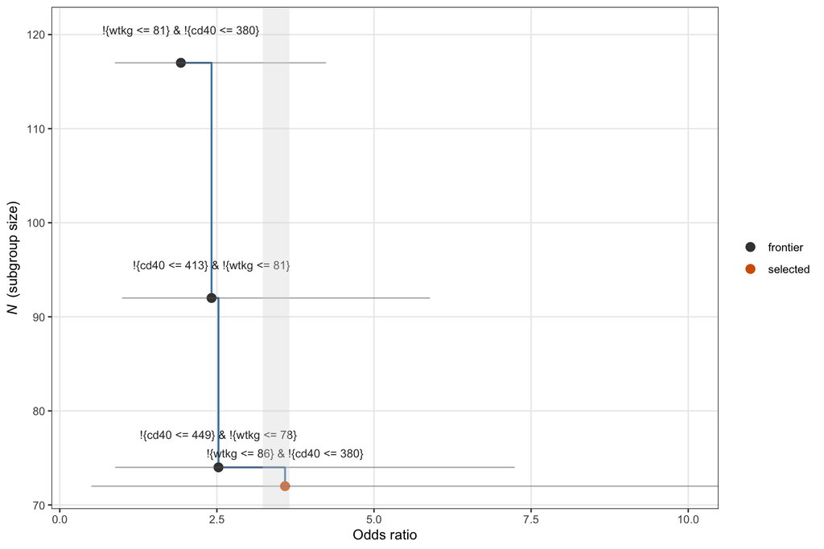

```r
# 1. Compute the split-derived CIs once (the expensive step).
ci_tab <- compute_frontier_cis(
  fs,
  n_splits = frontier_params$n_splits,
  seed     = frontier_params$seed
)

# 2. Plot, with split-derived CI bars overlaid; same intervals as the table.
p_pareto <- plot_pareto_frontier(
  fs,
  ci_table  = ci_tab,
  show_band = TRUE,
  xlim      = frontier_params$xlim
)
print(p_pareto)
```

```r
# 3. Render the table.  Selected subgroup is highlighted and marked with ★.
pareto_frontier_table(
  fs,
  ci_table = ci_tab,
  digits   = frontier_params$digits
)
```

Pareto frontier on (OR, N)

4 non-dominated candidate(s) | sg_focus = 'hrMaxSG' | OR shown on natural scale (exponentiated from log-scale storage) | diagnostic only

| S<sup>1,2</sup> | M.1 | M.2 | N | E | OR | P<sup>3</sup> | K | 95% CIs Naive | 95% CIs Split ~ | 95% CIs FSBC ~ |
| --- | --- | --- | --- | --- | --- | --- | --- | --- | --- | --- |
| ★ | !{wtkg <= 86} | !{cd40 <= 380} | 72 | 37 | 3.58 | 0.99 | 2 | (1.35, 9.50) | (0.50, 25.61) | 3.30 (0.46, 23.60) |
|  | !{cd40 <= 449} | !{wtkg <= 78} | 74 | 43 | 2.53 | 0.94 | 2 | (0.97, 6.55) | (0.88, 7.24) | 2.44 (0.85, 7.00) |
|  | !{cd40 <= 413} | !{wtkg <= 81} | 92 | 49 | 2.41 | 0.96 | 2 | (1.04, 5.59) | (0.99, 5.89) | 2.35 (0.96, 5.74) |
|  | !{wtkg <= 81} | !{cd40 <= 380} | 117 | 59 | 1.93 | 0.91 | 2 | (0.92, 4.02) | (0.88, 4.24) | 1.90 (0.86, 4.17) |

<sup>1</sup> S: selected subgroup (winner of the configured selection rule).  
<sup>2</sup> ★ marks the subgroup chosen by sg_focus = 'hrMaxSG'.  
<sup>3</sup> P: Pcons (consistency probability).

### 5.2.5 Selection Narrative

`explain_pareto_selection()` describes the chosen subgroup relative to the non-dominated alternatives on the frontier.

```r
cat(explain_pareto_selection(fs, ci_table = ci_tab))
```

**Selection criterion.** The configured criterion is largest-N within the effect-size band (sg_focus = “hrMaxSG”) under the effect-size neighborhood rule. The effect-size band requires odds ratio within 10% of the maximum on the frontier (i.e., odds ratio >= 3.226). Within the eligible set, ties on N are broken by Pcons, then by effect strength, then by parsimony (smaller K).

**Selected subgroup.** !{wtkg <= 86} AND !{cd40 <= 380} (odds ratio = 3.584, N = 72, Pcons = 0.990, K = 2). This is the largest-N candidate in the eligible set among non-dominated frontier candidates. The Naive 95% CI for the odds ratio on this subgroup is (1.352, 9.503).

**Non-selected frontier candidates** (ordered by closeness to winning):

- **!{cd40 <= 449} AND !{wtkg <= 78}** (odds ratio = 2.525, N = 74, Pcons = 0.940, K = 2). fell outside the effect-size band (odds ratio = 2.525 below the floor); excluded before the N tiebreaker even applies.
- **!{cd40 <= 413} AND !{wtkg <= 81}** (odds ratio = 2.415, N = 92, Pcons = 0.960, K = 2). fell outside the effect-size band (odds ratio = 2.415 below the floor); excluded before the N tiebreaker even applies.
- **!{wtkg <= 81} AND !{cd40 <= 380}** (odds ratio = 1.927, N = 117, Pcons = 0.910, K = 2). fell outside the effect-size band (odds ratio = 1.927 below the floor); excluded before the N tiebreaker even applies.

### 5.2.6 Agreement with GRF

ForestSearch and GRF identify subgroups by different mechanisms — FS via exhaustive search with consistency filtering, GRF via causal forests plus policy trees — so agreement on subject-level membership provides an informal robustness check. `compare_fs_subgroups()` produces a publication-ready cross-tabulation plus Cohen’s kappa; it accepts forestsearch and GRF result objects directly, and handles non-detection (method identifies no subgroup) by assigning all subjects to the complement.

```r
sg_compare <- compare_fs_subgroups(
  fs1               = fs,
  fs2               = grf_est,
  label1            = "ForestSearch",
  label2            = "GRF Standalone",
  id.name           = id.name,
  subgroup_notation = "harm",
  title             = "FS vs GRF: Subgroup Membership Concordance",
  subtitle          = "ACTG175 observed data (binary OR, adverse scale)",
  font_size         = 13
)
sg_compare$table
```

**FS vs GRF: Subgroup Membership Concordance**

ACTG175 observed data (binary OR, adverse scale)

| ForestSearch | GRF Standalone H (Questionable) | GRF Standalone Hᶜ (Recommend) | Total |  |
| --- | --- | --- | --- | --- |
| H (Questionable) | 67 | 5 |  | 72 |
| Hᶜ (Recommend) | 63 | 948 | 1011 |  |
| Total | 130 | 953 | 1083 |  |

**Agreement:** 1015 / 1083 (93.7%) **Cohen’s κ:** 0.632 **ForestSearch H:** !{wtkg <= 86} & !{cd40 <= 380} **GRF Standalone H:** (wtkg <= 83.462400000000002 & preanti > 1292) | (wtkg > 83.462400000000002 & cd40 > 390)

```r
cat("Concordance statistics:\n")
```

```
#> Concordance statistics:
```

```r
cat(sprintf("  Agreement:       %.1f%%\n",
    100 * sg_compare$concordance$agreement))
```

```
#>   Agreement:       93.7%
```

```r
if (!is.null(sg_compare$concordance$kappa)) {
  cat(sprintf("  Cohen's kappa:   %.3f\n", sg_compare$concordance$kappa))
}
```

```
#>   Cohen's kappa:   0.632
```

```r
cat(sprintf("  Concordant:      %d / Discordant: %d / Total: %d\n",
    sg_compare$concordance$n_agree,
    sg_compare$concordance$n_disagree,
    sg_compare$concordance$n_total))
```

```
#>   Concordant:      1015 / Discordant: 68 / Total: 1083
```

# 6 Bootstrap Bias Correction

## 6.1 Rationale

GLM estimates from identified subgroups are **upwardly biased** due to the selection process (subgroups are selected *because* they show extreme effects). Bootstrap bias correction addresses this by:

1. Resampling with replacement
2. Re-running the entire ForestSearch algorithm
3. Computing bias terms from bootstrap vs. observed estimates
4. Applying infinitesimal jackknife variance estimation

## 6.2 Running Bootstrap Analysis

```r
t0 <- proc.time()

fs_bc <- forestsearch_bootstrap_dofuture(
  fs.est = fs,
  nb_boots = NB,
  show_three = FALSE,
  details = FALSE,
  digits = construction_digits,
  parallel_args = list(
    plan = "multisession",
    workers = n_cores,
    show_message = TRUE
  )
)
```

```
#> Bootstrap parallel config: Using user-provided settings
```

```
#> System max cores available: 14
```

```
#> Bootstrap will use: 11 workers with 'multisession' plan
```

```
#> Parallel plan: multisession with 11 workers.
```

```
#> Bootstrap iteration 1/1000
```

```
#> Bootstrap iteration 10/1000
```

```
#> Bootstrap iteration 50/1000
```

```
#> Bootstrap iteration 100/1000
```

```
#> Bootstrap iteration 250/1000
```

```
#> Bootstrap iteration 500/1000
```

```
#> Bootstrap iteration 750/1000
```

```
#> Bootstrap iteration 1000/1000
```

```r
plan("sequential"); gc(verbose = FALSE)
```

```
#>           used  (Mb) gc trigger  (Mb) limit (Mb) max used  (Mb)
#> Ncells 3207041 171.3    4826439 257.8         NA  4826439 257.8
#> Vcells 8704671  66.5   35174371 268.4      36864 83014045 633.4
```

```r
timings$bootstrap <- (proc.time() - t0)["elapsed"]

cat("\nBootstrap completed in",
    round(timings$bootstrap / 60, 1), "minutes\n")
```

```
#>
#> Bootstrap completed in 15.1 minutes
```

## 6.3 Bootstrap Summary and Diagnostics

```r
# The OR column (with bias-corrected OR*) is auto-detected from FSsg_tab; the
# est.scale argument only affects the legacy HR-flavored caption helper.
summaries <- summarize_bootstrap_results(
  sgharm = fs$sg.harm,
  boot_results = fs_bc,
  create_plots = TRUE,
  est.scale = "hr",
  digits = display_digits
)
```

```
#>
#> ===============================================================
#>            BOOTSTRAP ANALYSIS SUMMARY
#> ===============================================================
#>
#> IDENTIFIED SUBGROUP:
#> -------------------------------------------------------------
#>   H: !{wtkg <= 86} & !{cd40 <= 380}
#>
#> BOOTSTRAP SUCCESS METRICS:
#> -------------------------------------------------------------
#>   Total iterations:              1000
#>   Successful subgroup ID:        990 (99.0%)
#>   Failed to find subgroup:       10 (1.0%)
#>
#> TIMING ANALYSIS:
#> -------------------------------------------------------------
#> Overall:
#>   Total bootstrap time:          15.07 minutes (0.25 hours)
#>   Average per iteration:         0.02 min (0.9 sec)
```

```r
summaries$table
```

**Treatment Effect by Subgroup**

Bootstrap bias-corrected estimates (1000 iterations)

| Subgroup | Sample Size N | Sample Size N<sub>T</sub> | Event Rates Rate<sub>C</sub> | Event Rates Rate<sub>T</sub> | Diff | Treatment Effect OR (95% CI)†<sup>1</sup> | Treatment Effect OR‡ (95% CI)<sup>2</sup> |
| --- | --- | --- | --- | --- | --- | --- | --- |
| Qstnbl<sup>3</sup> | 72 (6.6%) | 34 (47.2%) | 36.84% | 67.65% | +30.80% | 3.58 (1.35, 9.50) | 2.43 (0.80,7.33) |
| Recmnd | 1011 (93.4%) | 488 (48.3%) | 44.93% | 32.38% | -12.56% | 0.59 (0.45, 0.76) | 0.61 (0.41,0.89) |

<sup>1</sup> **Unadjusted OR**: GLM estimate with robust standard errors  
<sup>2</sup> **Bias-corrected OR**: Bootstrap-adjusted estimate using infinitesimal jackknife method (1000 iterations). Corrects for optimism in subgroup selection.  
<sup>3</sup> **Identified subgroup**: !{wtkg <= 86} & !{cd40 <= 380}  
*Note*: Rate<sub>C</sub> = control arm event rate; Rate<sub>T</sub> = treatment arm event rate. Subgroup identified in 99.0% of bootstrap samples.

## 6.4 Fast de-biased gate vs. full bootstrap

The Tier-2 de-biased gate is a fast multiplier-bootstrap approximation of the bootstrap bias-correction. It reuses per-candidate GLM influence (`dfbeta`) over the selection engine’s **own** candidate family — the enumerated consistency candidates, DINA’s qualifying cuts, or GRF’s DR-score frontier, depending on `fs_subgroup_method` — and re-selects under multiplier draws, so its selection-bias term mirrors the same search optimism the full bootstrap corrects — without re-running the search per resample. The table below compares the gate (computed inside the fit) against the full bootstrap from the previous section. The naive-OR row is a scale sanity check; agreement on the de-biased row is the Tier-2-vs-Tier-1 validation. By default the de-biased CI uses the same infinitesimal-jackknife variance as the full bootstrap (the `ci_method = 'ij'` default), so the de-biased row compares both point estimate and interval like-for-like. The gate de-biases both the selected subgroup and its complement, so both appear in the comparison and the table below.

Selected subgroup: !{wtkg <= 86} & !{cd40 <= 380} (complement = remaining subjects)

| quantity | Tier 2 (gate) | Tier 1 (bootstrap) |
| --- | --- | --- |
| naive OR (95% CI) | 3.584 (1.315, 9.774) | 3.584 (1.352, 9.503) |
| de-biased OR (95% CI) | 1.794 (0.633, 5.082) | 2.427 (0.803, 7.333) |
| complement naive OR (95% CI) | 0.587 (0.454, 0.759) | 0.587 (0.454, 0.758) |
| complement de-biased OR (95% CI) | 0.616 (0.370, 1.026) | 0.606 (0.411, 0.893) |

Scale cross-check (naive gate vs bootstrap H0): **PASS** (3.584 vs 3.584).

Candidate family: 2794 (full <= maxk space); screened survivors = 145.

Re-selection rule = `effMaxSG` (matches the consistency search statistic).

Timing: Tier 1 bootstrap (1000 boots) 904.9 s (15.1 min); Tier 2 gate 0.54 s -> **1660x** faster (multiplier loop only; the full bootstrap scales with `NB`, the gate does not).

Gate `mr_harm_confirmed` = **TRUE** (de-biased OR 1.794 vs gate 1.00); selection bias 0.6915 (log-OR). De-biased CI: infinitesimal jackknife (Tier-1 analogue) (IJ SE 0.531 vs robust SE 0.512, log-OR). Complement (n = 1011): naive OR 0.587 -> de-biased 0.616 (selection bias -0.0499, log-OR).

The same bias-corrected estimates table, rebuilt from the Tier-2 gate object. The descriptive columns and naive effect are tier-independent (inherited from the bootstrap result used as a template); the bias-corrected column carries the gate’s de-biased estimate for **both** the selected subgroup and its complement.

```r
mr_estimates_table(fs, boot_results = fs_bc, est.scale = "hr", digits = 2)
```

**Treatment Effect by Subgroup**

MR de-biased estimate (multiplier resampling, 5000 draws)

| Subgroup | Sample Size N | Sample Size N<sub>T</sub> | Event Rates Rate<sub>C</sub> | Event Rates Rate<sub>T</sub> | Diff | Treatment Effect OR (95% CI)†<sup>1</sup> | Treatment Effect OR‡ (95% CI)<sup>2</sup> |
| --- | --- | --- | --- | --- | --- | --- | --- |
| Qstnbl<sup>3</sup> | 72 (6.6%) | 34 (47.2%) | 36.84% | 67.65% | +30.80% | 3.58 (1.35, 9.50) | 1.79 (0.63,5.08) |
| Recmnd | 1011 (93.4%) | 488 (48.3%) | 44.93% | 32.38% | -12.56% | 0.59 (0.45, 0.76) | 0.62 (0.37,1.03) |

<sup>1</sup> **Unadjusted OR**: GLM estimate with robust standard errors  
<sup>2</sup> **Bias-corrected OR**: Bootstrap-adjusted estimate using infinitesimal jackknife method (5000 iterations). Corrects for optimism in subgroup selection.  
<sup>3</sup> **Identified subgroup**: !{wtkg <= 86} & !{cd40 <= 380}  
*Note*: Rate<sub>C</sub> = control arm event rate; Rate<sub>T</sub> = treatment arm event rate.

## 6.5 Subgroup Outcome Visualization

```r
fs_plot <- plot_sg_glm_outcomes(
  fs.est         = fs,
  outcome.name   = outcome.name,
  treat.name     = treat.name,
  effect_measure = fs_effect_measure,
  outcome_type   = fs_outcome_type,
  E.name         = "ZDV+ddI",
  C.name         = "ddI",
  show_itt       = TRUE,
  show_effect    = TRUE,
  verbose        = TRUE
)
```

```
#> ℹ Adding new coordinate system, which will replace the existing one.
```

```
#> Figure note: Identified subgroup (H): !{wtkg <= 86} & !{cd40 <= 380}. Bars show event rates per arm; error bars show 95 percent CI.
```

### 6.5.1 Bootstrap Diagnostics

```r
summaries$diagnostics_table_gt
```

**Bootstrap Diagnostics Summary**

Analysis of 1000 bootstrap iterations

| Category | Metric | Value |
| --- | --- | --- |
| Success Rate | Total iterations | 1000 |
|  | Successful | 990 (99.0%) |
|  | Failed | 10 (1.0%) |
|  | Success rating | Excellent |
| Subgroup H (Questionable) | Observed OR | 3.584 |
|  | Bias-corrected OR | 2.427 |
|  | Bootstrap CV (%) | 79.9% |
|  | N estimates | 990 |
| Subgroup Hc (Recommend) | Observed OR | 0.587 |
|  | Bias-corrected OR | 0.606 |
|  | Bootstrap CV (%) | 43.2% |
|  | N estimates | 990 |

### 6.5.2 Subgroup Agreement

How consistently does bootstrap identify the same subgroup?

```r
if (!is.null(summaries$subgroup_summary$original_agreement)) {
  summaries$subgroup_summary$original_agreement
}
```

```
#>                             Metric                          Value
#>                             <char>                         <char>
#> 1:      Total bootstrap iterations                           1000
#> 2:           Successful iterations                            990
#> 3: Failed iterations (no subgroup)                             10
#> 4:
#> 5:    Original subgroup definition !{cd40 <= 380} & !{wtkg <= 86}
#> 6:       Exact match with original                      31 (3.1%)
#> 7:         Different from original                    959 (96.9%)
#> 8:   Partial match (shared factor)                    210 (21.2%)
```

```r
if (!is.null(summaries$subgroup_summary$factor_presence)) {
  summaries$subgroup_summary$factor_presence
}
```

```
#>    Rank  Factor Count    Percent
#> 2     1    cd40   853 86.1616162
#> 12    2    wtkg   759 76.6666667
#> 9     3 preanti   147 14.8484848
#> 3     4    cd80    89  8.9898990
#> 1     5     age    48  4.8484848
#> 8     6  karnof    30  3.0303030
#> 5     7  gender    13  1.3131313
#> 4     8   drugs    12  1.2121212
#> 10    9    race    12  1.2121212
#> 7    10    homo    10  1.0101010
#> 11   11 symptom     6  0.6060606
#> 6    12    hemo     1  0.1010101
```

### 6.5.3 Bootstrap Distributions

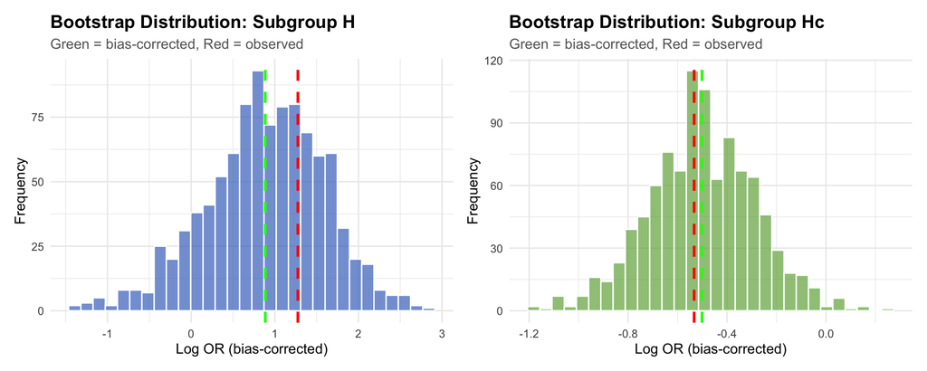

Bootstrap distributions of OR for H (questionable) and Hc (recommend)

```r
if (!is.null(summaries$plots)) {
  summaries$plots$H_distribution + summaries$plots$Hc_distribution
}
```

# 7 DINA-Based Subgroup Identification

DINA (Doubly-robust Identification of Non-Additive effects) screens and selects subgroups from an influence-function representation of the covariate-specific treatment effect, fit with cross-fitting. For a binary endpoint the DINA family is `"binomial"` and the effect is reported on the OR scale. It plugs into the ForestSearch workflow in three complementary ways, all configured to mirror the main analysis above (same confounders, harm threshold, minimum size `n.min = 60`, and `sg_focus`):

- **(A)** ForestSearch *using DINA for screening* — DINA’s per-covariate frontier contributes candidate cuts to the screening pool; the consistency search still performs selection.
- **(B)** *Standalone DINA* with parameters analogous to (A) — the same fit’s frontier (the candidates (A) screens) and its single selected subgroup via `dina_subgroup()`.
- **(C)** ForestSearch with `subgroup_method = "dina"` — subgroup *selection* is delegated to `dina_subgroup()`, then the standard ForestSearch bootstrap provides the selection bias-corrected OR estimate.

```r
# Shared DINA *fit* settings (binary outcome => family mapped to "binomial").
# Selection parameters (sg_focus, or_threshold) live in the setup chunk under
# the fs_dina_* knobs so they can be tuned independently; (B) and (C) read them.
dina_seed   <- 8316951L
dina_nfolds <- 2L
# Harm/benefit floor on the natural-parameter (log-OR) link scale for the
# binomial family.
m_diff_dina <- log(fs_dina_or_threshold)
```

## 7.1 (A) ForestSearch Using DINA for Screening

```r
t0 <- proc.time()

fs_dina_screen <- forestsearch(
  # --- Required data + roles ----------------------------------------------
  df.analysis               = actg_df,
  confounders.name          = confounders.name,
  outcome.name              = outcome.name,
  event.name                = outcome.name,
  treat.name                = treat.name,
  id.name                   = id.name,
  is.RCT                    = TRUE,
  seedit                    = analysis_seed,
  # --- GLM parameters -----------------------------------------------------
  outcome_type              = fs_outcome_type,
  effect_measure            = fs_effect_measure,
  adverse_outcome           = TRUE,
  # --- Screening engines: GRF + LASSO + DINA ------------------------------
  use_lasso                 = TRUE,
  use_grf                   = TRUE,
  grf_depth                 = 2L,
  dmin.grf                  = 0,
  frac.tau                  = 0.80,
  vi.grf.min                = -0.2,
  return_selected_cuts_only = TRUE,
  tune_grf                  = FALSE,
  use_dina                  = TRUE,
  dina_args = list(
    seed = dina_seed, n_folds = dina_nfolds,
    scope = "wide", max_per_covariate = 3L, max_subgroups = 10L,
    selected_only = dina_screen_selected_only
  ),
  # --- Candidate-cut construction -----------------------------------------
  cut_type                  = "default",
  cont.cutoff               = 4L,
  conf.cont_jcuts           = list(cd40 = 10, wtkg = 10),
  # --- Selection engine ---------------------------------------------------
  subgroup_method           = "consistency",
  sg_focus                  = dina_screen_sg_focus,
  selection_rule            = "neighborhood",
  effect_neighborhood       = 0.10,
  # --- Subgroup constraints -----------------------------------------------
  n.min                     = 60L,
  d0.min                    = 10L,
  d1.min                    = 10L,
  maxk                      = 2L,
  # --- Thresholds (OR scale) ----------------------------------------------
  effect.threshold          = dina_screen_or_threshold,
  consistency.threshold     = dina_screen_or_consistency,
  pconsistency.threshold    = fs_pconsistency,
  consistency_method        = fs_consistency_method,
  # --- Consistency search -------------------------------------------------
  fs.splits                 = 500L,
  use_twostage              = TRUE,
  # --- Output / diagnostics -----------------------------------------------
  show_candidate_summary    = TRUE,
  details                   = TRUE,
  quiet                     = FALSE,
  plot.sg                   = FALSE,
  # --- Parallel -----------------------------------------------------------
  parallel_args = list(
    plan = "multisession",
    workers = n_cores,
    show_message = TRUE
  )
)
```

```
#>
#> [forestsearch] Subgroup Identification Configuration
#>   Outcome type:   binary
#>   Effect measure: OR (Odds Ratio)
#>   Scale:          log (ratio)
#>
#>   Screening:      OR >= 1.00 (log: 0.0000)
#>   Consistency:    OR >= 0.90 (log: -0.1054)
#>   Consistency rate threshold: 90%
#>
#>   Interpretation:
#>     Candidates: subgroup OR >= 1.00
#>     Splits:     each split OR >= 0.90
```

```
#>   Search Alignment Diagnostic
```

```
#>
#>   Outcome:    y_binary_neg (binary)
```

```
#>   Treatment:  treat
```

```
#>   Measure:    Odds Ratio (OR) -- estimator sees Y as-is (no flip)
```

```
#>
#>   ForestSearch searches for:
#>     Subgroups where treat increases P(y_binary_neg=1)
#>     (OR >= threshold on the ORIGINAL outcome scale)
```

```
#>
#>   Thresholds:
#>     Screening: OR >= 1.000 in the candidate subgroup
#>     Consistency: OR >= 0.900 in each bootstrap split
```

```
#>
#>   Variable screening:
```

```
#>     LASSO: LASSO screening uses glmnet with family = "binomial (logistic)".
#>     Variables with non-zero coefficients are retained.
```

```
#>     GRF:   GRF sees 1-y_binary_neg (flipped for causal_forest).
#>     Positive CATE = treatment REDUCES y_binary_neg = treatment HELPS.
```

```
#>
#>   No alignment concerns detected.
```

```
#> J-quantile cuts: cd40 (J=10), wtkg (J=10)
#> GRF subgroup: (wtkg <= 83 & preanti > 1292) | (wtkg > 83 & cd40 > 390)
#> GRF cuts identified: 3
#>   Cuts: wtkg <= 83, preanti <= 1292, cd40 <= 390
#> DINA screening mode: selected cut (dina_subgroup, forestsearch criteria)
#> DINA cuts identified: 2
#>   Cuts: cd40 >= 500, drugs <= 0
#> Cox-LASSO selected: 7 of 13 candidate factors
#>   Omitted: wtkg, karnof, hemo, drugs, gender, symptom
#> Candidate factors: 39
#>  [1] "wtkg <= 83.4624" "preanti <= 1292" "cd40 <= 390"     "cd40 >= 500"
#>  [5] "cd40 <= 204"     "cd40 <= 237"     "cd40 <= 267"     "cd40 <= 296"
#>  [9] "cd40 <= 321"     "cd40 <= 350"     "cd40 <= 380"     "cd40 <= 413"
#> [13] "cd40 <= 449"     "cd40 <= 507"     "wtkg <= 58"      "wtkg <= 64"
#> [17] "wtkg <= 67"      "wtkg <= 70"      "wtkg <= 73"      "wtkg <= 76"
#> [21] "wtkg <= 78"      "wtkg <= 81"      "wtkg <= 86"      "wtkg <= 91"
#> [25] "age <= 35"       "age <= 34"       "age <= 29"       "age <= 40"
#> [29] "preanti <= 382"  "preanti <= 136"  "preanti <= 0"    "preanti <= 745"
#> [33] "cd80 <= 988"     "cd80 <= 895"     "cd80 <= 649"     "cd80 <= 1208"
#> [37] "homo"            "race"            "drugs <= 0"
#> Number of possible configurations (<= maxk): maxk = 2 , # combinations = 3081
#> Per-arm events criteria: control >= 10, treatment >= 10
#> Sample size criteria: n >= 60
#> Subgroup search completed in 0.04 minutes
#>
#> --- Filtering Summary ---
#>   Combinations evaluated: 3081
#>   Passed variance check: 2899
#>   Passed prevalence (>= 0.025 ): 2899
#>   Passed redundancy check: 2751
#>   Passed events counts (d0>= 10, d1>= 10): 2435
#>   Passed sample size (n>= 60 ): 2356
#>   GLM model fit successfully: 2356
#>   Passed effect threshold (effect >= 0.0000): 168
#> -------------------------
#>
#> Found 168 subgroup candidate(s)
#> # of candidate subgroups (meeting all criteria) = 168
#> Removed 3 near-duplicate subgroups
#> # of unique initial candidates: 165
```

[output cut: 8 more lines]

```
#>    1   6.337     71    41    2  *   *   !{wtkg <= 83.4624} & !{cd40 <= 413}
#>    2   1.096    262   133    2  *   -   {drugs <= 0} & !{cd40 <= 413}
#>    3   1.120    207    89    2  *   -   !{wtkg <= 81} & !{cd40 <= 296}
#>    4   1.152    197    99    2  *   -   !{cd40 <= 390} & !{wtkg <= 73}
#>    5   1.404    177    85    2  *   -   !{wtkg <= 76} & !{cd40 <= 380}
#>    6   1.445    159    69    2  *   -   !{wtkg <= 83.4624} & !{cd40 <= 296}
#>    7   1.598    156    75    2  *   -   !{cd40 <= 390} & !{wtkg <= 76}
#>    8   1.700    136    64    2  *   -   !{wtkg <= 83.4624} & !{cd40 <= 321}
#>    9   1.718    134    65    2  *   -   !{cd40 <= 390} & !{wtkg <= 78}
#>   10   1.927    117    59    2  *   -   !{cd40 <= 380} & !{wtkg <= 81}
#> ... 155 more candidates not shown (max_print = 10).
#> --------------------------------------------------------------------------------------------------------------
#> To evaluate: 165   On frontier: 13   In band: 1
#> Legend: OF = on Pareto frontier;  IB = in effect-size band.
#> ==============================================================================================================
```

```
#> Parallel plan: multisession with 11 workers.
```

```
#> Parallel config: workers = 11 , batch_size = 22
#> Batch 1 / 8 : candidates 1 - 22
#> Batch 2 / 8 : candidates 23 - 44
#> Batch 3 / 8 : candidates 45 - 66
#> Batch 4 / 8 : candidates 67 - 88
#> Batch 5 / 8 : candidates 89 - 110
#> Batch 6 / 8 : candidates 111 - 132
#> Batch 7 / 8 : candidates 133 - 154
#> Batch 8 / 8 : candidates 155 - 165
#> Evaluated 165 of 165 candidates (complete)
#> 17 subgroups passed consistency threshold
#> SG focus = hrMaxSG
#>
#> ==============================================================================================================
#> CANDIDATE EVALUATION SUMMARY  (sg_focus = "hrMaxSG", selection_rule = "neighborhood")
#> ==============================================================================================================
#> Rank  OR      N      E     K    P      OF  IB  S  Subgroup
#> --------------------------------------------------------------------------------------------------------------
#>    1   6.337     71    41    2  1.000  *   *   *  !{wtkg <= 83.4624} & !{cd40 <= 413}
#>    2   1.598    156    75    2  0.920  *   -   -  !{cd40 <= 390} & !{wtkg <= 76}
#>    3   1.700    136    64    2  0.930  *   -   -  !{wtkg <= 83.4624} & !{cd40 <= 321}
#>    4   1.602    136    69    2  0.900  -   -   -  !{cd40 <= 413} & !{wtkg <= 76}
#>    5   1.718    134    65    2  0.930  *   -   -  !{cd40 <= 390} & !{wtkg <= 78}
#>    6   1.927    117    59    2  0.950  *   -   -  !{cd40 <= 380} & !{wtkg <= 81}
#>    7   1.739    116    53    2  0.910  -   -   -  !{wtkg <= 83.4624} & !{cd40 <= 350}
#>    8   1.813    115    59    2  0.930  -   -   -  !{cd40 <= 413} & !{wtkg <= 78}
#>    9   2.395    107    54    2  0.980  *   -   -  !{cd40 <= 390} & !{wtkg <= 81}
#>   10   1.917    105    51    2  0.940  -   -   -  !{cd40 <= 321} & !{wtkg <= 86}
#> ... 7 more candidates not shown (max_print = 10).
#> --------------------------------------------------------------------------------------------------------------
#> Evaluated: 165   Passed: 17   On frontier: 8   In band: 1   Selected: m=1
#> Legend: P = Pcons (consistency probability); OF = on Pareto frontier;  IB = in effect-size band; S = selected.
#> ==============================================================================================================
#>
#> Seconds and minutes forestsearch overall = 11.319 0.1886
#> Consistency algorithm used: twostage
#> Subgroup identified: !{wtkg <= 83.4624} & !{cd40 <= 413}
```

```r
plan("sequential"); gc(verbose = FALSE)
```

```
#>            used  (Mb) gc trigger  (Mb) limit (Mb) max used  (Mb)
#> Ncells  3561756 190.3    7287031 389.2         NA  7287031 389.2
#> Vcells 11869966  90.6   35174371 268.4      36864 83014045 633.4
```

```r
timings$fs_dina_screen <- (proc.time() - t0)["elapsed"]

if (!is.null(fs_dina_screen$sg.harm) && length(fs_dina_screen$sg.harm) > 0) {
  cat("Identified subgroup (H):",
      fmt_sg(fs_dina_screen$sg.harm), "\n")
  cat("Subgroup size:", sum(fs_dina_screen$df.est$treat.recommend == 0),
      sprintf("(%.1f%% of ITT)\n",
              100 * mean(fs_dina_screen$df.est$treat.recommend == 0)))
} else {
  cat("DINA-screened ForestSearch: no subgroup identified.\n")
}
```

```
#> Identified subgroup (H): !{wtkg <= 83.46} & !{cd40 <= 413}
#> Subgroup size: 71 (6.6% of ITT)
```

```r
dina_screen_cuts <- fs_dina_screen$dina_cuts
if (length(dina_screen_cuts) > 0) {
  gt(data.frame(
    `#` = seq_along(dina_screen_cuts),
    `DINA candidate cut` = dina_screen_cuts,
    check.names = FALSE
  )) |>
    tab_header(title = "DINA Screening Candidates Injected into ForestSearch") |>
    cols_align(align = "left")
} else {
  cat("DINA contributed no candidate cuts under the configured frontier.\n")
}
```

DINA Screening Candidates Injected into ForestSearch

| # | DINA candidate cut |
| --- | --- |
| 1 | cd40 >= 500 |
| 2 | drugs <= 0 |

```r
# Selection diagnostic for the DINA-screened run (selected subgroup marked).
pareto_frontier_table(fs_dina_screen)
```

Pareto frontier on (OR, N)

8 non-dominated candidate(s) | sg_focus = 'hrMaxSG' | OR shown on natural scale (exponentiated from log-scale storage) | diagnostic only

| S<sup>1,2</sup> | M.1 | M.2 | N | E | OR | P<sup>3</sup> | K |
| --- | --- | --- | --- | --- | --- | --- | --- |
| ★ | !{wtkg <= 83.4624} | !{cd40 <= 413} | 71 | 41 | 6.34 | 1.00 | 2 |
|  | !{wtkg <= 83.4624} | !{cd40 <= 390} | 83 | 44 | 4.92 | 1.00 | 2 |
|  | !{wtkg <= 83.4624} | !{cd40 <= 380} | 92 | 48 | 3.57 | 1.00 | 2 |
|  | !{cd40 <= 390} | !{wtkg <= 81} | 107 | 54 | 2.39 | 0.98 | 2 |
|  | !{cd40 <= 380} | !{wtkg <= 81} | 117 | 59 | 1.93 | 0.95 | 2 |
|  | !{cd40 <= 390} | !{wtkg <= 78} | 134 | 65 | 1.72 | 0.93 | 2 |
|  | !{wtkg <= 83.4624} | !{cd40 <= 321} | 136 | 64 | 1.70 | 0.93 | 2 |
|  | !{cd40 <= 390} | !{wtkg <= 76} | 156 | 75 | 1.60 | 0.92 | 2 |

<sup>1</sup> S: selected subgroup (winner of the configured selection rule).  
<sup>2</sup> ★ marks the subgroup chosen by sg_focus = 'hrMaxSG'.  
<sup>3</sup> P: Pcons (consistency probability).

## 7.2 (B) Standalone DINA

```r
t0 <- proc.time()

# Standalone DINA -- dina(), dina_frontier(), dina_subgroup() -- on the numeric
# covariate frame (all candidates are numeric per `data-covariates`).
dina_fit <- dina(
  df         = actg_df,
  outcome    = outcome.name,
  treatment  = treat.name,
  covariates = confounders.name,
  family     = "binomial",     # binary outcome (no status column required)
  # ... forwarded to dina_fit():
  seed              = dina_seed,   # default NULL
  n_folds           = dina_nfolds, # default 2L
  propensity_method = "logistic",  # default "logistic"
  cross_fitting     = TRUE         # default TRUE
)

timings$dina_standalone <- (proc.time() - t0)["elapsed"]
cat("Standalone DINA fit complete (family = binomial).\n")
```

```
#> Standalone DINA fit complete (family = binomial).
```

### 7.2.1 DINA Frontier (Screening Candidates)

```r
dina_fr <- dina_frontier(
  fit               = dina_fit,
  df                = actg_df,
  covariates        = confounders.name,
  scope             = "wide",     # default "wide"; or "harm" (requires m_diff)
  m_diff            = NULL,        # default NULL (no effect floor under scope = "wide")
  n_min             = 60L,        # default 60L
  direction         = "both",     # default "both"; or "left" / "right"
  max_per_covariate = 3L,         # default 3L
  max_subgroups     = 10L,        # default 10L
  digits            = 3L          # default 3L
)

gt(dina_fr[, c("covariate", "direction", "threshold",
               "n_subgroup", "effect", "cut_expr")]) |>
  tab_header(
    title = "Standalone DINA Frontier",
    subtitle = "Per-covariate non-dominated (effect, N) candidates; effect on OR scale"
  ) |>
  fmt_number(columns = c(threshold, effect), decimals = 3) |>
  cols_label(
    covariate = "Covariate", direction = "Direction",
    threshold = "Threshold", n_subgroup = "N", effect = "OR",
    cut_expr = "Cut"
  ) |>
  cols_align(align = "left", columns = c(covariate, direction, cut_expr))
```

Standalone DINA Frontier

Per-covariate non-dominated (effect, N) candidates; effect on OR scale

| Covariate | Direction | Threshold | N | OR | Cut |
| --- | --- | --- | --- | --- | --- |
| cd40 | right | 549.000 | 62 | 1.149 | cd40 >= 549 |
| cd80 | right | 1,786.000 | 69 | 1.019 | cd80 >= 1790 |
| preanti | right | 1,224.000 | 67 | 0.979 | preanti >= 1220 |
| symptom | right | 1.000 | 192 | 0.754 | symptom >= 1 |
| age | left | 29.000 | 282 | 0.722 | age <= 29 |
| homo | right | 1.000 | 725 | 0.718 | homo >= 1 |
| karnof | left | 90.000 | 457 | 0.692 | karnof <= 90 |
| drugs | left | 0.000 | 941 | 0.681 | drugs <= 0 |
| race | right | 1.000 | 311 | 0.674 | race >= 1 |
| wtkg | left | 57.607 | 95 | 0.662 | wtkg <= 57.6 |

### 7.2.2 DINA-Selected Subgroup

```r
dina_sel <- dina_subgroup(
  fit                 = dina_fit,
  df                  = actg_df,
  covariates          = confounders.name,
  m_diff              = m_diff_dina,
  n_min               = 60L,            # default 60L
  direction           = "both",         # default "both"; or "left" / "right"
  sg_focus            = fs_dina_sg_focus,
  selection_rule      = "neighborhood", # default "neighborhood"; pareto/both
  effect_neighborhood = 0.10,           # default 0.10
  alpha               = 0.05            # default 0.05
)

if (isTRUE(dina_sel$found)) {
  op <- if (identical(dina_sel$direction, "left")) "<=" else ">="
  cat(sprintf("DINA-selected subgroup: %s %s %s\n",
              dina_sel$covariate, op, format(dina_sel$threshold)))
  cat(sprintf("Direction: %s | N = %d\n",
              dina_sel$direction, dina_sel$n_subgroup))
} else {
  cat("Standalone DINA selected no subgroup meeting the criteria.\n")
}
```

[output not shown]

## 7.3 (C) ForestSearch with `subgroup_method = "dina"`

In this mode ForestSearch delegates subgroup *selection* to `dina_subgroup()`, bypassing GRF, LASSO and the consistency search. The selection criteria are inherited from this call’s `sg_focus`, `n.min` and `effect.threshold` (mapped to the log-OR harm floor); `dina_args` supplies only the fit tuning. The returned object is a standard `forestsearch` result, so the existing bootstrap machinery applies unchanged.

```r
t0 <- proc.time()

fs_dina <- forestsearch(
  # --- Required data + roles ----------------------------------------------
  df.analysis         = actg_df,
  confounders.name    = confounders.name,
  outcome.name        = outcome.name,
  event.name          = outcome.name,
  treat.name          = treat.name,
  id.name             = id.name,
  is.RCT              = TRUE,
  seedit              = analysis_seed,
  # --- GLM parameters -----------------------------------------------------
  outcome_type        = fs_outcome_type,
  effect_measure      = fs_effect_measure,
  adverse_outcome     = TRUE,
  # --- DINA-selection mode ------------------------------------------------
  subgroup_method     = "dina",
  dina_args           = list(seed = dina_seed, n_folds = dina_nfolds),  # fit tuning only
  dina_select_statistic = fs_dina_select_statistic,
  # --- Selection criteria (passed through to dina_subgroup) ---------------
  sg_focus            = fs_dina_sg_focus,
  selection_rule      = "neighborhood",
  effect_neighborhood = 0.10,
  n.min               = 60L,
  effect.threshold    = fs_dina_or_threshold,  # -> log-OR harm floor
  # --- Tier-2 de-biased gate ----------------------------------------------
  mr_inference         = run_mr,
  mr_inference_args    = list(draws = mr_draws,
                             family_native_neighborhood = fs_dina_family_native_nbhd),
  # --- Output -------------------------------------------------------------
  details             = TRUE
  # NOTE: subgroup_method = "dina" bypasses GRF, LASSO and the consistency
  # search; use_grf / use_lasso / use_twostage / fs.splits / maxk and related
  # parameters do not apply in this mode.
)
```

```
#>
#> [forestsearch] DINA selection (subgroup_method = "dina")
#>   Family:              binomial
#>   sg_focus:            hrMaxSG
#>   selection_rule:      neighborhood
#>   effect_neighborhood: 0.1
#>   Harm floor:          m_diff = 0.0000  (hr.threshold = 1)
#>   n.min:               60
#>   DINA frontier candidates (per-covariate non-dominated):
#>      covariate direction threshold n_subgroup    effect        cut_expr
#>           cd40     right  549.0000         62 1.1488938     cd40 >= 549
#>           cd80     right 1786.0000         69 1.0191980    cd80 >= 1790
#>        preanti     right 1224.0000         67 0.9794775 preanti >= 1220
#>        symptom     right    1.0000        192 0.7535221    symptom >= 1
#>            age      left   29.0000        282 0.7219017       age <= 29
#>           homo     right    1.0000        725 0.7177058       homo >= 1
#>         karnof      left   90.0000        457 0.6923732    karnof <= 90
#>          drugs      left    0.0000        941 0.6814438      drugs <= 0
#>           race     right    1.0000        311 0.6740014       race >= 1
#>           wtkg      left   57.6072         95 0.6616176    wtkg <= 57.6
```

```
#>   Candidates searched:  10284
#>   Candidates qualifying (>= floor, >= n.min): 147
#>   SELECTED: {preanti >= 849.4} & {cd40 >= 338.0}  (n = 98, mean tau-hat = 0.0098)
```

```
#> DINA-selected subgroup: {preanti >= 849.40000000000009} & {cd40 >= 338}
```

```
#> Multiplier resampling (MR): constructing de-biased estimates from 5000 draws.
#>   This is post-selection inference on the completed search; it cannot change the identified subgroup.
```

```r
timings$fs_dina_select <- (proc.time() - t0)["elapsed"]

if (!is.null(fs_dina$sg.harm) && length(fs_dina$sg.harm) > 0) {
  cat("DINA-selected subgroup (H):",
      fmt_sg(fs_dina$sg.harm), "\n")
  cat("Subgroup size:", sum(fs_dina$df.est$treat.recommend == 0),
      sprintf("(%.1f%% of ITT)\n",
              100 * mean(fs_dina$df.est$treat.recommend == 0)))
} else {
  cat("DINA selection: no subgroup met the criteria.\n")
}
```

```
#> DINA-selected subgroup (H): {preanti >= 849.4} & {cd40 >= 338}
#> Subgroup size: 98 (9.0% of ITT)
```

### 7.3.1 Bootstrap Bias-Corrected OR Estimates

The within-subgroup OR is upwardly biased by selection. The ForestSearch bootstrap corrects this by re-running the full pipeline on each resample; because the result above was produced in DINA-selection mode, each replicate re-fits DINA and re-runs `dina_subgroup()` from scratch — so the correction reflects the DINA selection process itself.

```r
# Runs only when DINA identified a subgroup.  The bootstrap bias-corrects an
# identified subgroup's effect, so there is nothing to do otherwise.
t0 <- proc.time()

fs_dina_bc <- forestsearch_bootstrap_dofuture(
  fs.est = fs_dina,
  nb_boots = NB,
  show_three = FALSE,
  details = FALSE,
  digits = construction_digits,
  parallel_args = list(
    plan = "multisession",
    workers = n_cores,
    show_message = TRUE
  )
)
```

```
#> Bootstrap parallel config: Using user-provided settings
```

```
#> System max cores available: 14
```

```
#> Bootstrap will use: 11 workers with 'multisession' plan
```

```
#> Parallel plan: multisession with 11 workers.
```

```
#> Bootstrap iteration 1/1000
```

```
#> Bootstrap iteration 10/1000
```

```
#> Bootstrap iteration 50/1000
```

```
#> Bootstrap iteration 100/1000
```

```
#> Bootstrap iteration 250/1000
```

```
#> Bootstrap iteration 500/1000
```

```
#> Bootstrap iteration 750/1000
```

```
#> Bootstrap iteration 1000/1000
```

```r
plan("sequential"); gc(verbose = FALSE)
```

```
#>            used  (Mb) gc trigger  (Mb) limit (Mb) max used  (Mb)
#> Ncells  3569620 190.7    7287031 389.2         NA  7287031 389.2
#> Vcells 12506805  95.5   35174371 268.4      36864 83014045 633.4
```

```r
timings$fs_dina_bootstrap <- (proc.time() - t0)["elapsed"]

cat("\nDINA-mode bootstrap completed in",
    round(timings$fs_dina_bootstrap / 60, 1), "minutes\n")
```

```
#>
#> DINA-mode bootstrap completed in 1 minutes
```

```r
# Shown only when DINA selected no subgroup at the configured harm floor.
timings$fs_dina_bootstrap <- 0
cat("DINA (subgroup_method = \"dina\") identified no subgroup at",
    "effect.threshold =", fs_dina_or_threshold, "-- bootstrap skipped.\n",
    "DINA's model-based effect is attenuated relative to the raw OR,",
    "so this floor may not be reached; see the standalone DINA frontier (B)",
    "for the achievable effect range, and lower the DINA harm floor if a",
    "bootstrap demonstration is desired.\n")
```

```r
dina_summaries <- summarize_bootstrap_results(
  sgharm = fs_dina$sg.harm,
  boot_results = fs_dina_bc,
  create_plots = FALSE,
  est.scale = "hr",
  digits = display_digits
)
```

```
#>
#> ===============================================================
#>            BOOTSTRAP ANALYSIS SUMMARY
#> ===============================================================
#>
#> IDENTIFIED SUBGROUP:
#> -------------------------------------------------------------
#>   H: {preanti >= 849.40000000000009} & {cd40 >= 338}
#>
#> BOOTSTRAP SUCCESS METRICS:
#> -------------------------------------------------------------
#>   Total iterations:              1000
#>   Successful subgroup ID:        978 (97.8%)
#>   Failed to find subgroup:       22 (2.2%)
#>
#> TIMING ANALYSIS:
#> -------------------------------------------------------------
#> Overall:
#>   Total bootstrap time:          1.03 minutes (0.02 hours)
#>   Average per iteration:         0.00 min (0.1 sec)
```

```r
dina_summaries$table
```

**Treatment Effect by Subgroup**

Bootstrap bias-corrected estimates (1000 iterations)

| Subgroup | Sample Size N | Sample Size N<sub>T</sub> | Event Rates Rate<sub>C</sub> | Event Rates Rate<sub>T</sub> | Diff | Treatment Effect OR (95% CI)†<sup>1</sup> | Treatment Effect OR‡ (95% CI)<sup>2</sup> |
| --- | --- | --- | --- | --- | --- | --- | --- |
| Qstnbl<sup>3</sup> | 98 (9.0%) | 43 (43.9%) | 49.09% | 65.12% | +16.03% | 1.94 (0.85, 4.40) | 0.85 (0.23,3.11) |
| Recmnd | 985 (91.0%) | 479 (48.6%) | 43.87% | 31.94% | -11.93% | 0.60 (0.46, 0.78) | 0.63 (0.40,1.02) |

<sup>1</sup> **Unadjusted OR**: GLM estimate with robust standard errors  
<sup>2</sup> **Bias-corrected OR**: Bootstrap-adjusted estimate using infinitesimal jackknife method (1000 iterations). Corrects for optimism in subgroup selection.  
<sup>3</sup> **Identified subgroup**: {preanti >= 849.40000000000009} & {cd40 >= 338}  
*Note*: Rate<sub>C</sub> = control arm event rate; Rate<sub>T</sub> = treatment arm event rate. Subgroup identified in 97.8% of bootstrap samples.

#### 7.3.1.1 Tier-2 de-biased gate (counterpart to the Tier-1 bootstrap)

The same Tier-2-vs-Tier-1 comparison as the main analysis, for the DINA-selection fit. The gate de-biases against DINA’s **own** qualifying candidate family (re-running nothing), while the bootstrap above re-runs DINA on every resample.

For DINA the two tiers are **not** expected to agree as tightly as for the consistency method. DINA selects on its model-based **tau-hat**, but the gate can only re-select on the perturbed **GLM** OR; over a large depth-2 candidate family the gate’s winner’s-curse term can therefore exceed the bootstrap’s and over-correct the selected subgroup. To keep the gate’s re-selection neighbourhood close to DINA’s own selection band, the gate by default restricts that family to candidates competitive on DINA’s native tau-hat, matching the band to `effect_neighborhood` (the recommended default, used here via `fs_dina_family_native_nbhd <- NULL`; set an explicit number for a different band, or `>= 1` to de-bias against the full unrestricted family). The complement is the induced residual rather than a max-over-family selection, so it agrees across tiers regardless. This band tunes only the *candidate-competition* part of the bias — the gate holds the DINA fit fixed, so the refit optimism is invisible to it; treat the full bootstrap as the reference for DINA and the gate as a fast, conservative check.

DINA-selected subgroup: {preanti >= 849.4} & {cd40 >= 338} (complement = remaining subjects)

| quantity | Tier 2 (gate) | Tier 1 (bootstrap) |
| --- | --- | --- |
| naive OR (95% CI) | 1.936 (0.837, 4.475) | 1.936 (0.852, 4.396) |
| de-biased OR (95% CI) | 0.955 (0.294, 3.098) | 0.851 (0.233, 3.106) |
| complement naive OR (95% CI) | 0.600 (0.463, 0.779) | 0.600 (0.463, 0.779) |
| complement de-biased OR (95% CI) | 0.632 (0.376, 1.062) | 0.634 (0.395, 1.017) |

Timing: Tier 1 bootstrap (1000 boots) 62.6 s (1.0 min); Tier 2 gate 0.15 s -> **415x** faster (the bootstrap scales with `NB`, the gate does not).

Gate harm flag = **FALSE** (de-biased OR 0.955 vs gate 1.00); selection bias 0.7081 (log-OR); candidate family = 147. Re-selection rule = `effMaxSG` (a GLM-OR proxy for DINA’s tau-hat); native-family band = default (matched to effect_neighborhood). De-biased CI: infinitesimal jackknife (Tier-1 analogue) (IJ SE 0.601 vs robust SE 0.428, log-OR).

The Tier-1 bias-corrected table above, rebuilt from the Tier-2 gate object (the descriptive columns and naive effect are tier-independent; the bias-corrected column carries the gate’s de-biased estimate for the subgroup and its complement).

```r
mr_estimates_table(fs_dina, boot_results = fs_dina_bc, est.scale = "hr", digits = 2)
```

**Treatment Effect by Subgroup**

MR de-biased estimate (multiplier resampling, 5000 draws)

| Subgroup | Sample Size N | Sample Size N<sub>T</sub> | Event Rates Rate<sub>C</sub> | Event Rates Rate<sub>T</sub> | Diff | Treatment Effect OR (95% CI)†<sup>1</sup> | Treatment Effect OR‡ (95% CI)<sup>2</sup> |
| --- | --- | --- | --- | --- | --- | --- | --- |
| Qstnbl<sup>3</sup> | 98 (9.0%) | 43 (43.9%) | 49.09% | 65.12% | +16.03% | 1.94 (0.85, 4.40) | 0.95 (0.29,3.10) |
| Recmnd | 985 (91.0%) | 479 (48.6%) | 43.87% | 31.94% | -11.93% | 0.60 (0.46, 0.78) | 0.63 (0.38,1.06) |

<sup>1</sup> **Unadjusted OR**: GLM estimate with robust standard errors  
<sup>2</sup> **Bias-corrected OR**: Bootstrap-adjusted estimate using infinitesimal jackknife method (5000 iterations). Corrects for optimism in subgroup selection.  
<sup>3</sup> **Identified subgroup**: {preanti >= 849.40000000000009} & {cd40 >= 338}  
*Note*: Rate<sub>C</sub> = control arm event rate; Rate<sub>T</sub> = treatment arm event rate.

## 7.4 (D) ForestSearch with `subgroup_method = "grf"`

In this mode ForestSearch delegates subgroup *selection* to GRF — a causal-forest policy tree (`grf_selection = "tree"`) or the doubly-robust-score frontier (`"frontier"`) — bypassing LASSO, DINA and the consistency search. The selection criteria are inherited from this call’s `sg_focus` (mapped to the GRF frontier/tree rule), `n.min`, `grf_depth`, `grf_selection` and the DR-score harm floor `dmin.grf` (on the RD scale for binary). The returned object is a standard `forestsearch` result, so the existing bootstrap machinery applies unchanged.

```r
t0 <- proc.time()

fs_grf <- forestsearch(
  # --- Required data + roles ----------------------------------------------
  df.analysis         = actg_df,
  confounders.name    = confounders.name,
  outcome.name        = outcome.name,
  event.name          = outcome.name,
  treat.name          = treat.name,
  id.name             = id.name,
  is.RCT              = TRUE,
  seedit              = analysis_seed,   # also seeds the forest
  # --- GLM parameters -----------------------------------------------------
  outcome_type        = fs_outcome_type,
  effect_measure      = fs_effect_measure,
  adverse_outcome     = TRUE,
  # --- GRF-selection mode -------------------------------------------------
  subgroup_method     = "grf",
  grf_selection       = fs_grf_demo_selection,   # "tree" | "frontier"
  grf_select_statistic = fs_grf_select_statistic, # frontier only
  grf_depth           = fs_grf_demo_depth,
  dmin.grf            = fs_grf_demo_dmin,          # DR-score harm floor (RD scale)
  frac.tau            = 0.8,
  # --- Selection criteria -------------------------------------------------
  sg_focus            = fs_grf_sg_focus,          # -> GRF frontier/tree rule
  selection_rule      = "neighborhood",
  effect_neighborhood = 0.10,
  n.min               = 60L,
  # --- Tier-2 de-biased gate ----------------------------------------------
  mr_inference         = run_mr,
  mr_inference_args    = list(draws = mr_draws,
                             family_native_neighborhood = fs_grf_family_native_nbhd),
  # --- Output -------------------------------------------------------------
  details             = TRUE
  # NOTE: subgroup_method = "grf" bypasses LASSO, DINA and the consistency
  # search; use_lasso / use_dina / use_twostage / fs.splits / maxk and related
  # parameters do not apply in this mode.
)
```

```
#>
#> [forestsearch] Subgroup Identification Configuration
#>   Outcome type:   binary
#>   Effect measure: OR (Odds Ratio)
#>   Scale:          log (ratio)
#>
#>   Screening:      OR >= 1.25 (log: 0.2231)
#>   Consistency:    OR >= 1.00 (log: 0.0000)
#>   Consistency rate threshold: 90%
#>
#>   Interpretation:
#>     Candidates: subgroup OR >= 1.25
#>     Splits:     each split OR >= 1.00
```

```
#>   Search Alignment Diagnostic
```

```
#>
#>   Outcome:    y_binary_neg (binary)
```

```
#>   Treatment:  treat
```

```
#>   Measure:    Odds Ratio (OR) -- estimator sees Y as-is (no flip)
```

```
#>
#>   ForestSearch searches for:
#>     Subgroups where treat increases P(y_binary_neg=1)
#>     (OR >= threshold on the ORIGINAL outcome scale)
```

```
#>
#>   Thresholds:
#>     Screening: OR >= 1.250 in the candidate subgroup
#>     Consistency: OR >= 1.000 in each bootstrap split
```

```
#>
#>   Variable screening:
```

```
#>     LASSO: LASSO screening: DISABLED
```

```
#>     GRF:   DISABLED
```

```
#>
#>   No alignment concerns detected.
```

```
#>
#> [forestsearch] GRF selection (subgroup_method = "grf")
#>   Outcome type:   binary
#>   grf_depth:      2
#>   dmin.grf:       0
#>   frac.tau:       0.8
#>   n.min:          60
#>   SELECTED (depth 2): wtkg > 84.369600000000005 & cd40 > 368.20000000000005
```

```
#> GRF-selected subgroup: {wtkg > 84.369600000000005} & {cd40 > 368.20000000000005}
```

```
#> Multiplier resampling (MR): constructing de-biased estimates from 5000 draws.
#>   This is post-selection inference on the completed search; it cannot change the identified subgroup.
```

```r
timings$fs_grf_select <- (proc.time() - t0)["elapsed"]

if (!is.null(fs_grf$sg.harm) && length(fs_grf$sg.harm) > 0) {
  cat("GRF-selected subgroup (H):",
      fmt_sg(fs_grf$sg.harm), "\n")
  cat("Subgroup size:", sum(fs_grf$df.est$treat.recommend == 0),
      sprintf("(%.1f%% of ITT)\n",
              100 * mean(fs_grf$df.est$treat.recommend == 0)))
} else {
  cat("GRF selection: no subgroup met the criteria.\n")
}
```

```
#> GRF-selected subgroup (H): {wtkg > 84.37} & {cd40 > 368.2}
#> Subgroup size: 95 (8.8% of ITT)
```

### 7.4.1 Bootstrap Bias-Corrected OR Estimates

The within-subgroup OR is upwardly biased by selection. The ForestSearch bootstrap corrects this by re-running the full pipeline on each resample; because the result above was produced in GRF-selection mode, each replicate re-fits the causal forest and re-runs GRF selection from scratch — so the correction reflects the GRF selection process itself.

```r
# Runs only when GRF identified a subgroup.
t0 <- proc.time()

fs_grf_bc <- forestsearch_bootstrap_dofuture(
  fs.est = fs_grf,
  nb_boots = NB,
  show_three = FALSE,
  details = FALSE,
  digits = construction_digits,
  parallel_args = list(
    plan = "multisession",
    workers = n_cores,
    show_message = TRUE
  )
)
```

```
#> Bootstrap parallel config: Using user-provided settings
```

```
#> System max cores available: 14
```

```
#> Bootstrap will use: 11 workers with 'multisession' plan
```

```
#> Parallel plan: multisession with 11 workers.
```

```
#> Bootstrap iteration 1/1000
```

```
#> Bootstrap iteration 10/1000
```

```
#> Bootstrap iteration 50/1000
```

```
#> Bootstrap iteration 100/1000
```

```
#> Bootstrap iteration 250/1000
```

```
#> Bootstrap iteration 500/1000
```

```
#> Bootstrap iteration 750/1000
```

```
#> Bootstrap iteration 1000/1000
```

```r
plan("sequential"); gc(verbose = FALSE)
```

```
#>            used  (Mb) gc trigger  (Mb) limit (Mb) max used  (Mb)
#> Ncells  3735739 199.6    7287031 389.2         NA  7287031 389.2
#> Vcells 15665040 119.6   54923591 419.1      36864 83014045 633.4
```

```r
timings$fs_grf_bootstrap <- (proc.time() - t0)["elapsed"]

cat("\nGRF-mode bootstrap completed in",
    round(timings$fs_grf_bootstrap / 60, 1), "minutes\n")
```

```
#>
#> GRF-mode bootstrap completed in 5.7 minutes
```

```r
# Shown only when GRF selected no subgroup at the configured DR-score floor.
timings$fs_grf_bootstrap <- 0
cat("GRF (subgroup_method = \"grf\") identified no subgroup at",
    "dmin.grf =", fs_grf_demo_dmin, "-- bootstrap skipped.\n",
    "Lower the DR-score floor (dmin.grf) or switch grf_selection /",
    "grf_depth if a bootstrap demonstration is desired.\n")
```

```r
grf_summaries <- summarize_bootstrap_results(
  sgharm = fs_grf$sg.harm,
  boot_results = fs_grf_bc,
  create_plots = FALSE,
  est.scale = "hr",
  digits = display_digits
)
```

```
#>
#> ===============================================================
#>            BOOTSTRAP ANALYSIS SUMMARY
#> ===============================================================
#>
#> IDENTIFIED SUBGROUP:
#> -------------------------------------------------------------
#>   H: {wtkg > 84.369600000000005} & {cd40 > 368.20000000000005}
#>
#> BOOTSTRAP SUCCESS METRICS:
#> -------------------------------------------------------------
#>   Total iterations:              1000
#>   Successful subgroup ID:        1000 (100.0%)
#>   Failed to find subgroup:       0 (0.0%)
#>
#> TIMING ANALYSIS:
#> -------------------------------------------------------------
#> Overall:
#>   Total bootstrap time:          5.68 minutes (0.09 hours)
#>   Average per iteration:         0.01 min (0.3 sec)
```

```r
grf_summaries$table
```

**Treatment Effect by Subgroup**

Bootstrap bias-corrected estimates (1000 iterations)

| Subgroup | Sample Size N | Sample Size N<sub>T</sub> | Event Rates Rate<sub>C</sub> | Event Rates Rate<sub>T</sub> | Diff | Treatment Effect OR (95% CI)†<sup>1</sup> | Treatment Effect OR‡ (95% CI)<sup>2</sup> |
| --- | --- | --- | --- | --- | --- | --- | --- |
| Qstnbl<sup>3</sup> | 95 (8.8%) | 47 (49.5%) | 39.58% | 59.57% | +19.99% | 2.25 (0.99, 5.11) | 1.09 (0.40,3.01) |
| Recmnd | 988 (91.2%) | 475 (48.1%) | 44.83% | 32.21% | -12.62% | 0.58 (0.45, 0.76) | 0.63 (0.38,1.04) |

<sup>1</sup> **Unadjusted OR**: GLM estimate with robust standard errors  
<sup>2</sup> **Bias-corrected OR**: Bootstrap-adjusted estimate using infinitesimal jackknife method (1000 iterations). Corrects for optimism in subgroup selection.  
<sup>3</sup> **Identified subgroup**: {wtkg > 84.369600000000005} & {cd40 > 368.20000000000005}  
*Note*: Rate<sub>C</sub> = control arm event rate; Rate<sub>T</sub> = treatment arm event rate. Subgroup identified in 100.0% of bootstrap samples.

#### 7.4.1.1 Tier-2 de-biased gate (counterpart to the Tier-1 bootstrap)

The same Tier-2-vs-Tier-1 comparison as the main analysis, for the GRF-selection fit. The gate de-biases against GRF’s **own** DR-score candidate family (re-running nothing), while the bootstrap above re-runs GRF on every resample.

GRF-selected subgroup: {wtkg > 84.37} & {cd40 > 368.2} (complement = remaining subjects)

| quantity | Tier 2 (gate) | Tier 1 (bootstrap) |
| --- | --- | --- |
| naive OR (95% CI) | 2.249 (0.972, 5.203) | 2.249 (0.990, 5.112) |
| de-biased OR (95% CI) | 1.097 (0.429, 2.804) | 1.091 (0.396, 3.010) |
| complement naive OR (95% CI) | 0.585 (0.451, 0.758) | 0.585 (0.451, 0.758) |
| complement de-biased OR (95% CI) | 0.622 (0.370, 1.044) | 0.627 (0.378, 1.039) |

Timing: Tier 1 bootstrap (1000 boots) 341.6 s (5.7 min); Tier 2 gate 0.30 s -> **1150x** faster (the bootstrap scales with `NB`, the gate does not).

The Tier-1 bias-corrected table above, rebuilt from the Tier-2 gate object.

```r
mr_estimates_table(fs_grf, boot_results = fs_grf_bc, est.scale = "hr", digits = 2)
```

**Treatment Effect by Subgroup**

MR de-biased estimate (multiplier resampling, 5000 draws)

| Subgroup | Sample Size N | Sample Size N<sub>T</sub> | Event Rates Rate<sub>C</sub> | Event Rates Rate<sub>T</sub> | Diff | Treatment Effect OR (95% CI)†<sup>1</sup> | Treatment Effect OR‡ (95% CI)<sup>2</sup> |
| --- | --- | --- | --- | --- | --- | --- | --- |
| Qstnbl<sup>3</sup> | 95 (8.8%) | 47 (49.5%) | 39.58% | 59.57% | +19.99% | 2.25 (0.99, 5.11) | 1.10 (0.43,2.80) |
| Recmnd | 988 (91.2%) | 475 (48.1%) | 44.83% | 32.21% | -12.62% | 0.58 (0.45, 0.76) | 0.62 (0.37,1.04) |

<sup>1</sup> **Unadjusted OR**: GLM estimate with robust standard errors  
<sup>2</sup> **Bias-corrected OR**: Bootstrap-adjusted estimate using infinitesimal jackknife method (5000 iterations). Corrects for optimism in subgroup selection.  
<sup>3</sup> **Identified subgroup**: {wtkg > 84.369600000000005} & {cd40 > 368.20000000000005}  
*Note*: Rate<sub>C</sub> = control arm event rate; Rate<sub>T</sub> = treatment arm event rate.

**NoteSelection statistic vs. the gate’s re-selection (GRF)**

GRF ranks candidates by the **doubly-robust score** (RD-based for binary), while the Tier-2 gate re-selects on the perturbed **GLM** OR. The two scales (additive RD vs. multiplicative odds) need not agree, so the gate is a *proxy* for GRF’s selection — the same approximation noted for DINA’s tau-hat. `family_native_neighborhood` restricts the gate family to DR-score-competitive candidates to keep that proxy close to GRF’s actual selection neighbourhood; the full bootstrap remains the reference because it re-runs the DR-score selection itself.

# 8 Cross-Validation

Cross-validation assesses the **stability** of the ForestSearch algorithm. Two approaches are available.

## 8.1 K-Fold Cross-Validation

```r
cat("K-Fold cross-validation skipped (run_cv = FALSE). Set run_cv <- TRUE",
    "in the parallel-setup chunk to run it.\n")
```

```
#> K-Fold cross-validation skipped (run_cv = FALSE). Set run_cv <- TRUE in the parallel-setup chunk to run it.
```

```r
t0 <- proc.time()

fs_kfold <- forestsearch_tenfold(
  fs.est = fs,
  sims = Ksims,
  Kfolds = 10L,
  details = FALSE,
  parallel_args = list(
    plan = "multisession",
    workers = n_cores,
    show_message = FALSE
  )
)

plan("sequential"); gc(verbose = FALSE)
timings$kfold <- (proc.time() - t0)["elapsed"]
metrics_tables <- cv_metrics_tables(fs_kfold)
metrics_tables
```

### 8.1.1 Diagnostic Tabulations

`summarize_cv_results()` consolidates the per-fold record into a panel of diagnostic tables: which subgroups the pipeline identified across resamples, which GRF cuts drove those identifications, when identification failed what the proximate cause was, and how confidently the successful identifications were made.

```r
cv_diag <- summarize_cv_results(
  cv_output         = fs_kfold,
  original_sg       = fs$sg.harm,
  original_grf_cuts = fs$grf_cuts,
  top_n             = 10L
)
```

```r
cv_diag$identification_summary
```

```r
cv_diag$grf_cut_summary
```

```r
cv_diag$no_subgroup_decomposition
```

```r
cv_diag$pconsistency_distribution
```

```r
cv_diag$fold_numeric_summary
```

```r
cv_diag$original_agreement
```

## 8.2 Out-of-Bag (N-Fold) Cross-Validation

N-fold CV (leave-one-out):

```r
cat("Leave-one-out (N-fold / OOB) skipped (run_loo = FALSE). Set run_loo <- TRUE",
    "in the parallel-setup chunk to run it.\n")
```

```
#> Leave-one-out (N-fold / OOB) skipped (run_loo = FALSE). Set run_loo <- TRUE in the parallel-setup chunk to run it.
```

```r
t0 <- proc.time()

fs_OOB <- forestsearch_Kfold(
  fs.est = fs,
  details = FALSE,
  Kfolds = nrow(fs$df.est),  # N-fold = leave-one-out
  parallel_args = list(
    plan = "multisession",
    workers = n_cores,
    show_message = TRUE
  )
)

plan("sequential"); gc(verbose = FALSE)
timings$oob <- (proc.time() - t0)["elapsed"]

# Summarize OOB results
cv_out <- forestsearch_KfoldOut(
  res = fs_OOB,
  details = FALSE,
  outall = TRUE
)

tables <- cv_summary_tables(cv_out)

tables$combined_table

tables$metrics_table
```

# 9 Results Visualization

## 9.1 Forest Plot

The forest plot summarizes treatment effects across the ITT population and the identified subgroup with bootstrap-bias-corrected OR (and cross-validation metrics when CV was run). OR is a ratio measure, so the axis is on the log scale.

```r
# Build the fs_results list dynamically based on what's been computed.
fs_results_list <- list(fs.est = fs)
if (exists("fs_bc")) fs_results_list$fs_bc <- fs_bc

cv_label_for_plot <- NULL
if (exists("fs_kfold")) {
  fs_results_list$fs_kfold <- fs_kfold
  cv_label_for_plot <- "10-fold CV"
} else if (exists("fs_OOB")) {
  fs_results_list$fs_kfold <- fs_OOB
  cv_label_for_plot <- "LOO CV"
}

forest_obj <- plot_subgroup_results_forestplot(
  fs_results     = fs_results_list,
  df_analysis    = actg_df,
  outcome.name   = outcome.name,
  event.name     = outcome.name,
  treat.name     = treat.name,
  E.name         = "ZDV+ddI",
  C.name         = "ddI",
  outcome_type   = fs_outcome_type,
  effect_measure = fs_effect_measure,
  xlog           = TRUE,                 # OR is ratio scale -> log axis
  arrow_text     = c("Favors ZDV+ddI", "Favors ddI"),
  title_text     = "ACTG175 Subgroup Results — Binary (OR, adverse scale)",
  show_cv_metrics = !is.null(cv_label_for_plot),
  cv_source      = "kfold",
  xlim_method    = "data"
)
```

```
#> refline_lwd, refline_lty, refline_col will be deprecated, use refline_gp instead.
```

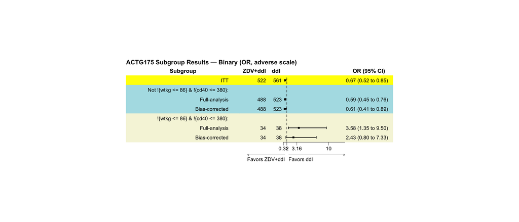

Subgroup forest plot; OR on the adverse scale (no improvement)

```r
render_forestplot(forest_obj)
```

```r
if (!is.null(cv_label_for_plot)) {
  cat(sprintf("\nCV annotations source: %s.\n", cv_label_for_plot))
}
```

# 10 Summary and Interpretation

## 10.1 Key Findings

```r
cat(strrep("=", 60), "\n")
cat("FORESTSEARCH ANALYSIS SUMMARY\n")
```

```
#> FORESTSEARCH ANALYSIS SUMMARY
```

```r
cat(strrep("=", 60), "\n\n")
cat("Dataset: ACTG175 (N =", nrow(actg_df), ")\n")
```

```
#> Dataset: ACTG175 (N = 1083 )
```

```r
cat("Outcome: binary, no CD4 improvement (adverse scale), OR measure\n\n")
```

```
#> Outcome: binary, no CD4 improvement (adverse scale), OR measure
```

```r
cat("ITT Analysis (adverse scale):\n")
```

```
#> ITT Analysis (adverse scale):
```

```r
cat(sprintf("  OR (95%% CI): %.2f (%.2f, %.2f)\n\n", itt_or, itt_ci_lo, itt_ci_hi))
```

```
#>   OR (95% CI): 0.67 (0.52, 0.85)
```

```r
if (!is.null(fs$sg.harm) && length(fs$sg.harm) > 0) {
  cat("Identified Subgroup (H):\n")
  cat("  Definition:", fmt_sg(fs$sg.harm), "\n")
  cat("  Size:", sum(fs$df.est$treat.recommend == 0),
      sprintf("(%.1f%%)\n", 100 * mean(fs$df.est$treat.recommend == 0)))

  cat("\nComplement Subgroup (Hc):\n")
  cat("  Size:", sum(fs$df.est$treat.recommend == 1),
      sprintf("(%.1f%%)\n", 100 * mean(fs$df.est$treat.recommend == 1)))
} else {
  cat("No harm subgroup was identified at the configured thresholds.\n")
}
```

```
#> Identified Subgroup (H):
#>   Definition: !{wtkg <= 86} & !{cd40 <= 380}
#>   Size: 72 (6.6%)
#>
#> Complement Subgroup (Hc):
#>   Size: 1011 (93.4%)
```

## 10.2 Interpretation Notes

The ForestSearch analysis identifies a subgroup where the treatment is associated with elevated odds of no CD4 improvement (harm on the adverse scale). As an exploratory result it requires the usual caveats:

1. This is an **exploratory** analysis requiring independent validation.
2. The bias-corrected (Tier-1 bootstrap and Tier-2 gate) estimates have wider confidence intervals than the naive subgroup OR.
3. Cross-validation metrics should be evaluated for algorithm stability.

The Tier-1/Tier-2 comparison is the methodological focus: for the consistency engine the gate is expected to track the full bootstrap closely on both point estimate and IJ interval; for DINA and GRF the gate is a fast, conservative proxy (it holds the engine’s fit fixed), so the full bootstrap remains the reference.

## 10.3 Computational Timing

```r
timings$total <- (proc.time() - t_vignette_start)["elapsed"]

timing_df <- data.frame(
  Analysis = c("GRF (preliminary)", "ForestSearch", "Bootstrap",
               "FS (DINA screening)", "DINA (standalone)",
               "FS (subgroup_method=dina)", "FS DINA bootstrap",
               "FS (subgroup_method=grf)", "FS GRF bootstrap",
               "kfold", "oob", "Total"),
  Seconds = c(
    timings$grf,
    timings$forestsearch,
    timings$bootstrap,
    timings$fs_dina_screen,
    timings$dina_standalone,
    timings$fs_dina_select,
    if (!is.null(timings$fs_dina_bootstrap)) timings$fs_dina_bootstrap else NA_real_,
    timings$fs_grf_select,
    if (!is.null(timings$fs_grf_bootstrap)) timings$fs_grf_bootstrap else NA_real_,
    timings$kfold,
    timings$oob,
    timings$total
  )
)
timing_df$Minutes <- timing_df$Seconds / 60

gt(timing_df) |>
  tab_header(title = "Computational Timing") |>
  fmt_number(columns = c(Seconds, Minutes), decimals = 1) |>
  cols_label(
    Analysis = "Component",
    Seconds = "Time (sec)",
    Minutes = "Time (min)"
  )
```

Computational Timing

| Component | Time (sec) | Time (min) |
| --- | --- | --- |
| GRF (preliminary) | 0.6 | 0.0 |
| ForestSearch | 13.0 | 0.2 |
| Bootstrap | 904.9 | 15.1 |
| FS (DINA screening) | 11.6 | 0.2 |
| DINA (standalone) | 0.0 | 0.0 |
| FS (subgroup_method=dina) | 0.9 | 0.0 |
| FS DINA bootstrap | 62.6 | 1.0 |
| FS (subgroup_method=grf) | 4.0 | 0.1 |
| FS GRF bootstrap | 341.6 | 5.7 |
| kfold | NA | NA |
| oob | NA | NA |
| Total | 1,346.4 | 22.4 |

# 11 References

León LF, Jemielita T, Guo Z, Marceau West R, Anderson KM (2024). “Exploratory subgroup identification in the heterogeneous Cox model: A relatively simple procedure.” *Statistics in Medicine*. DOI: 10.1002/sim.10163

Hammer SM, Katzenstein DA, Hughes MD, et al. (1996). A trial comparing nucleoside monotherapy with combination therapy in HIV-infected adults with CD4 cell counts from 200 to 500 per cubic millimeter. AIDS Clinical Trials Group Study 175 Study Team. *N Engl J Med*. 335(15):1081-90.

# 13 Reproducibility payload (Section 6.2)

The chunk below harvests the already-computed objects from the three engine runs into one small list and writes it as an `.rds` for the manuscript Section 6.2 reader document to reproduce the table and the results overview. No analysis is repeated; the output path, core count, and package version resolve at run time.

```
#> Wrote Section 6.2 payload to: /Users/larryleon/Documents/GitHub/forestsearch/quarto/applications/actg175/_payloads/analysis_actg175_binary_multimethod_fixed_family/analysis_actg175_binary_multimethod_fixed_family_payload.rds
```